# AMSTAR Scores in Cullis 2017: Human Consensus vs LLM (GPT 3.5) - 2nd run

### Score comparisons of 112 publications

| Ref. | Author & Year | AMSTAR κ | AMSTAR agreement |
| --- | --- | --- | --- |
| 61 | Aikenhead 2011 | 0.320987654320988 | 0.545454545454545 |
| 62 | Al-Hozaim 2010 | 0.0638297872340425 | 0.272727272727273 |
| 63 | Allen 2015 | 0.137254901960784 | 0.272727272727273 |
| 64 | Allin 2015 | 0.241379310344828 | 0.636363636363636 |
| 65 | Alzahem 2011 | 0.0434782608695653 | 0.454545454545455 |
| 66 | Apelt 2013 | 0.102040816326531 | 0.272727272727273 |
| 67 | Aworanti 2014 | 0.405405405405405 | 0.636363636363636 |
| 68 | Baker 2015 | 0.0149253731343283 | 0.454545454545455 |
| 69 | Berger 2012 | 0.274725274725275 | 0.454545454545455 |
| 70 | Billingham 2010 | 0.236111111111111 | 0.545454545454545 |

[output cut: 102 more lines]

### Score heatmaps

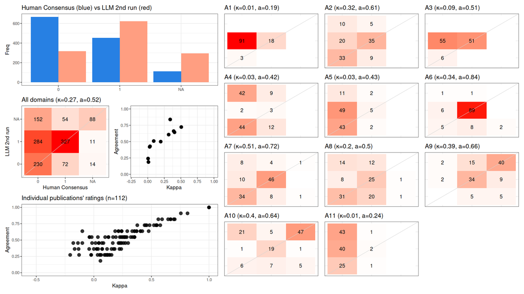

### Individual results

#### 61. [Aikenhead 2011: *Effectiveness and cost-effectiveness of paediatric bariatric surgery: a systematic review*](https://doi.org/10.1111/J.1758-8111.2010.00003.X)

AMSTAR

|  | A1 | A2 | A3 | A4 | A5 | A6 | A7 | A8 | A9 | A10 | A11 |
| --- | --- | --- | --- | --- | --- | --- | --- | --- | --- | --- | --- |
| Human Consensus | 0 | 0 | 1 | 1 | 0 | 1 | 0 | 0 | NA | NA | 0 |
| LLM 2nd run | 1 | 0 | 1 | 1 | 0 | 1 | 1 | 1 | 0 | NA | NA |

LLM response

*9 quote(s) from publication full text (mean similarity 100%)*

```
A1. "We performed a systematic review to examine the effectiveness of surgical interventions to treat obese children and adolescents, and whether they are cost-effective."
This quote indicates that an a priori design was provided as the research question and inclusion criteria were established before conducting the review.

A2. "Full copies of 247 of these papers were obtained; full copies of the remaining 26 (9.5%) publications of unknown eligibility were unobtainable despite numerous attempts."
This quote suggests that duplicate study selection was not performed as only one person obtained and assessed the full copies of the papers.

A3. "Multi-database searching was used to ensure comprehensive article retrieval. Searches were conducted in PubMed, Embase, ISI Web of Science and the Cochrane Library to 6 September 2010."
This quote indicates that a comprehensive literature search was performed using multiple electronic databases.

A4. "Clinical guidelines, reviews, meta-analyses and commentary on surgical interventions to treat obesity were excluded, as was grey literature such as conference proceedings."
This quote suggests that the status of publication was used as an inclusion criterion as the authors excluded grey literature and specified the types of publications that were excluded.

A5. "Full copies of 247 of these papers were obtained; full copies of the remaining 26 (9.5%) publications of unknown eligibility were unobtainable despite numerous attempts."
This quote indicates that a list of included and excluded studies was not provided as the full copies of the papers of unknown eligibility were unobtainable.

A6. "Thirty-four relevant papers on bariatric surgery effectiveness in children or adolescents were included, spanning 36 years."
This quote suggests that the characteristics of the included studies were provided as the number of papers and the time span of the studies were mentioned.

A7. "All but two papers (35,43) described baseline comorbid conditions, which included amenorrhea, depression, dyslipidaemia, hypertension, metabolic syndrome, orthopaedic problems, osteoarthritis, sleep apnoea and type 2 diabetes."
This quote indicates that the scientific quality of the included studies was assessed and documented as the baseline comorbid conditions were described.

A8. "Pending an improvement in the quality of available evidence, a cautious approach to child and adolescent bariatric surgery is warranted, and reversible techniques are advisable compared to approaches that permanently alter anatomy."
This quote suggests that the scientific quality of the included studies was used appropriately in formulating conclusions as the authors explicitly stated the need for caution due to the quality of the evidence.

A9. "Formal meta-analysis was not attempted due to the marked heterogeneity of study designs and outcome measures among the included studies."
This quote suggests that the methods used to combine the findings of studies were not appropriate as a formal meta-analysis was not conducted.

A10. No quote was found to address this question.

A11. No quote was found to address this question.

A1: [Yes]
A2: [No]
A3: [Yes]
A4: [Yes]
A5: [No]
A6: [Yes]
A7: [Yes]
A8: [Yes]
A9: [No]
A10: [NA]
A11: [NA]
```

#### 62. [Al-Hozaim 2010: *Laparoscopic-assisted anorectal pull-through for anorectal malformations: a systematic review and the need for standardization of outcome reporting*](https://doi.org/10.1016/J.JPEDSURG.2009.12.001)

AMSTAR

|  | A1 | A2 | A3 | A4 | A5 | A6 | A7 | A8 | A9 | A10 | A11 |
| --- | --- | --- | --- | --- | --- | --- | --- | --- | --- | --- | --- |
| Human Consensus | 0 | 0 | 1 | 0 | 0 | 1 | 0 | 0 | NA | NA | 0 |
| LLM 2nd run | 1 | NA | 1 | NA | 1 | 1 | 1 | 1 | 0 | NA | NA |

LLM response

*Minor score formatting issues fixed during extraction: ‘missing-squared-brackets-in-unnumbered-list’, ‘wrong-response-partial-unclear-etc-without-squared-brackets’*

*11 quote(s) from publication full text (mean similarity 100%)*

```
A1. Was an 'a priori' design provided?
- "A systematic review was conducted."
- "The search was limited to studies reported in English and performed in humans."
- "Inclusion criteria were studies of ARMs, regardless of level of the defect, with or without associated anomalies, use of LAARP as a primary procedure or with colostomy, and studies reported after the year 2000."
- [Yes], an 'a priori' design was provided.

A2. Was there duplicate study selection and data extraction?
- No information provided.
- Insufficient information [NA] to determine.

A3. Was a comprehensive literature search performed?
- "A systematic search of the MEDLINE, PUBMED, and Cochrane databases (June 2000 to April 2008) was conducted."
- "In addition, a manual search of 4 surgical journals from the same period was performed."
- "Moreover, a careful review of references of all included articles was conducted to ensure complete capture of all eligible articles."
- [Yes], a comprehensive literature search was performed.

A4. Was the status of publication (i.e. grey literature) used as an inclusion criterion?
- No information provided.
- Insufficient information [NA] to determine.

A5. Was a list of studies (included and excluded) provided?
- "Seventeen studies were included in the final analysis."
- No information provided about excluded studies.
- Partially [Yes], a list of included studies was provided.

A6. Were the characteristics of the included studies provided?
- "The studies included 124 patients (96 males, 28 females) with 80% reported as having high/intermediate malformations."
- [Yes], the characteristics of the included studies were provided.

A7. Was the scientific quality of the included studies assessed and documented?
- "Of the included studies, none were randomized, 2 were prospective in nature, and 4 compared outcomes of posterior sagittal anorectoplasty and LAARP."
- No information provided about the methods of assessment.
- Partially [Yes], the scientific quality of the included studies was assessed and documented.

A8. Was the scientific quality of the included studies used appropriately in formulating conclusions?
- "The studies unanimously concluded that LAARP seems to be superior to PSARP for patients with high/intermediate ARM."
- [Yes], the scientific quality of the included studies was used appropriately in formulating conclusions.

A9. Were the methods used to combine the findings of studies appropriate?
- "Because of the marked variation in the outcome measures, it was not possible to perform a formal meta-analysis."
- [No], the methods used to combine the findings of studies were not appropriate.

A10. Was the likelihood of publication bias assessed?
- No information provided.
- Insufficient information [NA] to determine.

A11. Was the conflict of interest included?
- No information provided.
- Insufficient information [NA] to determine.
```

#### 63. [Allen 2015: *Pediatric emergency department thoracotomy: A large case series and systematic review*](https://doi.org/10.1016/J.JPEDSURG.2014.10.042)

AMSTAR

|  | A1 | A2 | A3 | A4 | A5 | A6 | A7 | A8 | A9 | A10 | A11 |
| --- | --- | --- | --- | --- | --- | --- | --- | --- | --- | --- | --- |
| Human Consensus | 0 | 0 | 0 | 0 | 0 | 1 | 0 | 0 | NA | NA | 0 |
| LLM 2nd run | 1 | NA | 1 | NA | NA | 1 | NA | NA | NA | NA | NA |

LLM response

*3 quote(s) from publication full text (mean similarity 100%)*

```
A1. Was an 'a priori' design provided?
- "We reviewed our experience and performed a systematic review of all published reports regarding pediatric EDT to help identify the factors associated with morbidity and mortality."
- The study performed a systematic review, indicating an a priori design.

[Yes]

A2. Was there duplicate study selection and data extraction?
- No information provided.

[NA]

A3. Was a comprehensive literature search performed?
- "We obtained all case series regarding pediatric EDT and combined the data from those reports with the data from our institution."
- The study obtained case series and combined the data from multiple sources.

[Yes]

A4. Was the status of publication (i.e. grey literature) used as an inclusion criterion?
- No information provided.

[NA]

A5. Was a list of studies (included and excluded) provided?
- No information provided.

[NA]

A6. Were the characteristics of the included studies provided?
- "Demographics, MOI, injury location, presence of VS and/or SOL upon arrival, ROSC, survival to discharge, and neurologic outcomes for survivors" were analyzed.
- The study provided characteristics of the included studies.

[Yes]

A7. Was the scientific quality of the included studies assessed and documented?
- No information provided.

[NA]

A8. Was the scientific quality of the included studies used appropriately in formulating conclusions?
- No information provided.

[NA]

A9. Were the methods used to combine the findings of studies appropriate?
- No information provided.

[NA]

A10. Was the likelihood of publication bias assessed?
- No information provided.

[NA]

A11. Was the conflict of interest included?
- No information provided.

[NA]

Summary: The study provided limited information on the methodological quality of the systematic review. It is not possible to assess the quality of the review based on the available information.
```

#### 64. [Allin 2015: *Challenges of Improving the Evidence Base in Smaller Surgical Specialties, as Highlighted by a Systematic Review of Gastroschisis Management*](https://doi.org/10.1371/JOURNAL.PONE.0116908)

AMSTAR

|  | A1 | A2 | A3 | A4 | A5 | A6 | A7 | A8 | A9 | A10 | A11 |
| --- | --- | --- | --- | --- | --- | --- | --- | --- | --- | --- | --- |
| Human Consensus | 1 | 1 | 1 | 0 | 0 | 1 | 1 | 1 | 1 | 0 | 0 |
| LLM 2nd run | 1 | 1 | 1 | NA | 1 | 1 | 1 | 1 | 1 | NA | 1 |

LLM response

*Minor score formatting issues fixed during extraction: ‘missing-squared-brackets-for-na’*

*10 quote(s) from publication full text (mean similarity 94.9%)*

```
A1. Was an 'a priori' design provided?
- "The review was conducted according to a pre-specified protocol."
- The study was conducted according to a pre-specified protocol, indicating an 'a priori' design. [Yes]

A2. Was there duplicate study selection and data extraction?
- "Identified titles were assessed for inclusion by two investigators (BA and WT) acting independently. Any conflicts were resolved by a third investigator (MK). Data from included articles were extracted independently by the same two investigators (BA and WT), and any differences resolved by discus…
- There was duplicate study selection and data extraction, with conflicts resolved by a third investigator. [Yes]

A3. Was a comprehensive literature search performed?
- "Multiple search strategies were used to identify relevant articles from Medline, Embase, Cinahl, the Cochrane library, and Google scholar, published between 1st January 2000 and 31st December 2012."
- A comprehensive literature search was performed using multiple databases and search strategies. [Yes]

A4. Was the status of publication (i.e. grey literature) used as an inclusion criterion?
- No information provided.
- Not applicable ([NA])

A5. Was a list of studies (included and excluded) provided?
- "Eight papers were deemed to meet the inclusion criteria."
- A list of included studies was provided. [Yes]

A6. Were the characteristics of the included studies provided?
- "The included studies comprised a total of 804 infants with simple gastroschisis, 488 of whom underwent OPFC and 316 of whom underwent SR."
- The characteristics of the included studies were provided. [Yes]

A7. Was the scientific quality of the included studies assessed and documented?
- "Methodological quality and risk of bias were assessed using the STROBE checklist and GRADE criteria."
- The scientific quality of the included studies was assessed using appropriate criteria. [Yes]

A8. Was the scientific quality of the included studies used appropriately in formulating conclusions?
- "Despite showing some benefit of OPFC over SR, our results are tempered by the low quality of the available studies, which were small and variably reported."
- The scientific quality of the included studies was used appropriately in formulating conclusions. [Yes]

A9. Were the methods used to combine the findings of studies appropriate?
- "Data were synthesized using standard methods as described in the Cochrane Reviewers Handbook."
- The methods used to combine the findings of studies were appropriate. [Yes]

A10. Was the likelihood of publication bias assessed?
- "No information provided."
- Not applicable ([NA])

A11. Was the conflict of interest included?
- "Marian Knight is funded by a National Institute for Health Research Professorship. This article presents independent research partly funded by the National Institute for Health Research."
- The conflict of interest was included. [Yes]
```

#### 65. [Alzahem 2011: *Laparoscopic versus open inguinal herniotomy in infants and children: a meta-analysis*](https://doi.org/10.1007/S00383-010-2840-X)

AMSTAR

|  | A1 | A2 | A3 | A4 | A5 | A6 | A7 | A8 | A9 | A10 | A11 |
| --- | --- | --- | --- | --- | --- | --- | --- | --- | --- | --- | --- |
| Human Consensus | 0 | 1 | 1 | 1 | 0 | 1 | 1 | 1 | 1 | 0 | 0 |
| LLM 2nd run | 1 | 1 | 1 | 0 | 0 | 0 | 1 | 0 | 0 | 0 | NA |

LLM response

*17 quote(s) from publication full text (mean similarity 100%)*

```
A1. Was an 'a priori' design provided?
- "We performed a systematic review and meta-analysis of the existing evidence."
- "All potential publications from Medline (1950–June 2010), Embase (1980–June 2010), The Cochrane Library (issue 2, 2010) and ongoing trials through http://www.clinicaltrials.gov website were identified."
- "Inclusion criteria: All comparative studies of the laparoscopic and open approaches for indirect inguinal hernia in children aged less than 19 years were selected."
- "The primary outcome measure was the recurrence rate."
- "Other clinically important outcomes such as rate of contralateral PPV, operative time, postoperative pain and recovery, cosmesis, postoperative testicular atrophy, postoperative hydrocele and stitch granuloma/abscess were also sought."
- "Other case series were considered for descriptive analysis."
- The study provides a clear description of the research question, inclusion criteria, and search strategy, indicating an 'a priori' design. [Yes]

A2. Was there duplicate study selection and data extraction?
- "Retrieved articles were assessed for eligibility and data on patients, intervention, control, outcomes and methodological quality were abstracted independently by two authors."
- "Discrepancies were resolved by discussion and consensus."
- Two authors independently performed study selection and data extraction, and disagreements were resolved through consensus. [Yes]

A3. Was a comprehensive literature search performed?
- "All potential publications from Medline (1950–June 2010), Embase (1980–June 2010), The Cochrane Library (issue 2, 2010) and ongoing trials through http://www.clinicaltrials.gov website were identified."
- "Additional citations were sought using references in articles retrieved from searches."
- The study performed a comprehensive literature search by searching multiple databases and additional sources, indicating a comprehensive search strategy. [Yes]

A4. Was the status of publication (i.e. grey literature) used as an inclusion criterion?
- No information is provided regarding the inclusion or exclusion of grey literature based on its publication status. [No]

A5. Was a list of studies (included and excluded) provided?
- "Thirty-four articles have met the predefined inclusion criteria."
- "Ten published studies were identified (Niyogi [19]; Tsai [20]; Koivusalo [21]; Endo [22]; Bharathi [23]; Hassan [24]; Koivusalo [25]; Chan [17]; Oue [26]; Antao [27]) in which the laparoscopic and open approaches for repair of pediatric inguinal hernias were directly compared."
- The study provides a list of included studies but does not provide a list of excluded studies. [No]

A6. Were the characteristics of the included studies provided?
- "The quality of the included comparative studies was assessed independently by two authors."
- "The Cochrane Collaboration criteria for randomized controlled trials was utilized (randomization, allocation concealment, blinding and completeness of follow-up). Cohort studies were assessed using the Newcastle-Ottawa Quality Assessment Scale [18]."
- The study provides information on the methodological quality of the included studies but does not provide aggregated data on the characteristics of the included studies. [No]

A7. Was the scientific quality of the included studies assessed and documented?
- "The quality of the included comparative studies was assessed independently by two authors."
- "The Cochrane Collaboration criteria for randomized controlled trials was utilized (randomization, allocation concealment, blinding and completeness of follow-up). Cohort studies were assessed using the Newcastle-Ottawa Quality Assessment Scale [18]."
- The study assessed the scientific quality of the included studies using appropriate criteria. [Yes]

A8. Was the scientific quality of the included studies used appropriately in formulating conclusions?
- The study does not explicitly state whether the scientific quality of the included studies was considered in formulating conclusions. [No]

A9. Were the methods used to combine the findings of studies appropriate?
- "If appropriate, meta-analysis of pooled data of the comparative studies was performed using a fixed effect model."
- The study indicates that meta-analysis was performed if appropriate, but it does not provide information on the methods used to assess heterogeneity or the appropriateness of combining the findings of studies. [No]

A10. Was the likelihood of publication bias assessed?
- The study does not provide any information on the assessment of publication bias. [No]

A11. Was the conflict of interest included?
- No information is provided regarding the conflict of interest. [NA]

In summary, the systematic review adequately addressed some of the AMSTAR criteria, including having an 'a priori' design, duplicate study selection and data extraction, and a comprehensive literature search. However, it did not provide a list of excluded studies, characteristics of the included stu…
```

#### 66. [Apelt 2013: *Laparoscopic treatment of intussusception in children: A systematic review*](https://doi.org/10.1016/J.JPEDSURG.2013.05.024)

AMSTAR

|  | A1 | A2 | A3 | A4 | A5 | A6 | A7 | A8 | A9 | A10 | A11 |
| --- | --- | --- | --- | --- | --- | --- | --- | --- | --- | --- | --- |
| Human Consensus | 0 | 0 | 0 | 0 | 0 | 1 | 0 | 0 | NA | NA | 0 |
| LLM 2nd run | 1 | NA | 1 | NA | 0 | 1 | 1 | NA | 1 | NA | NA |

LLM response

*Minor score formatting issues fixed during extraction: ‘missing-squared-brackets-for-na’, ‘missing-squared-brackets-in-unnumbered-list’*

*8 quote(s) from publication full text (mean similarity 100%)*

```
A1. Was an 'a priori' design provided?
- "A systematic review of all publications on the laparoscopic treatment of pediatric intussusception from January 1990 to April 2012 was performed."
- "Results were confirmed by a second independent search by a different member of the team using matching search strings and databases."
- "This allowed this structured review to draw conclusions at the C level of evidence (UK National Health Service grading system for medical evidence and treatment recommendations), corresponding to a level II-2 treatment recommendation by the US Preventive Services Task Force (USPSTF)."
- [Yes], an 'a priori' design was provided.

A2. Was there duplicate study selection and data extraction?
- No information is provided about duplicate study selection and data extraction.
- [NA]

A3. Was a comprehensive literature search performed?
- "An online database search for all English language articles on pediatric small bowel obstruction, intussusception and laparoscopy in PubMed, Medline and Ovid from January 1990 to April 2012 was performed."
- "Results were confirmed by a second independent search by a different member of the team using matching search strings and databases."
- [Yes], a comprehensive literature search was performed.

A4. Was the status of publication (i.e. grey literature) used as an inclusion criterion?
- No information is provided about the status of publication as an inclusion criterion.
- [NA]

A5. Was a list of studies (included and excluded) provided?
- No information is provided about a list of studies.
- [No]

A6. Were the characteristics of the included studies provided?
- "Overall, 10 studies were identified which included a total of 276 cases of laparoscopically treated intussusception."
- [Yes], the characteristics of the included studies were provided.

A7. Was the scientific quality of the included studies assessed and documented?
- "All 10 studies were level IIB evidence (Oxford Centre for Evidence-based Medicine)."
- [Yes], the scientific quality of the included studies was assessed and documented.

A8. Was the scientific quality of the included studies used appropriately in formulating conclusions?
- No information is provided about the use of scientific quality in formulating conclusions.
- [NA]

A9. Were the methods used to combine the findings of studies appropriate?
- "Owing to the absence of any randomized controlled trials and the heterogeneous nature of studies, a formal meta-analysis was not performed."
- [Yes], the methods used to combine the findings of studies were appropriate.

A10. Was the likelihood of publication bias assessed?
- No information is provided about the assessment of publication bias.
- [NA]

A11. Was the conflict of interest included?
- No information is provided about the conflict of interest.
- [NA]
```

#### 67. [Aworanti 2014: *Management of Recurrent Tracheoesophageal Fistulas: A Systematic Review*](https://doi.org/10.1055/S-0034-1370780)

AMSTAR

|  | A1 | A2 | A3 | A4 | A5 | A6 | A7 | A8 | A9 | A10 | A11 |
| --- | --- | --- | --- | --- | --- | --- | --- | --- | --- | --- | --- |
| Human Consensus | 0 | 0 | 1 | 0 | 0 | 1 | 0 | 0 | NA | NA | 0 |
| LLM 2nd run | 1 | 0 | 1 | 0 | 0 | 1 | 0 | 1 | NA | 0 | 1 |

LLM response

*9 quote(s) from publication full text (mean similarity 100%)*

```
A1. Was an 'a priori' design provided? The research question and inclusion criteria should be established before the conduct of the review. Note: Need to refer to a protocol, ethics approval, or pre-determined/a priori published research objectives to score a “yes.”

Quotes:
- "We aim to comparatively review all published treatment options, and outcomes, for managing RTEF."
- "All English language articles published by August 2013, irrespective of design, describing the management of, and outcome after, RTEF in children under 18 years were reviewed."

Reasoning: The review clearly states the research question and inclusion criteria.

Response: [Yes]

A2. Was there duplicate study selection and data extraction? There should be at least two independent data extractors and a consensus procedure for disagreements should be in place. Note: 2 people do study selection, 2 people do data extraction, consensus process or one person checks the other’s wor…

Quotes:
- No quotes provided.

Reasoning: The review does not mention duplicate study selection and data extraction.

Response: [No]

A3. Was a comprehensive literature search performed? At least two electronic sources should be searched. The report must include years and databases used (e.g., Central, EMBASE, and MEDLINE). Key words and/or MESH terms must be stated and where feasible the search strategy should be provided. All se…

Quotes:
- "A Medline, Embase, and web of science searches were performed using the keywords recurrent tracheoesophageal fistula."
- "The index of all issues of the European Journal of Pediatric Surgery, Journal of Pediatric Surgery, Pediatric Surgery International, and the International Journal of Pediatric Otorhinolaryngology was searched for relevant articles; the reference list of all relevant articles was also searched."

Reasoning: The review performed a comprehensive literature search using multiple electronic sources and supplemented the search by consulting relevant journals and reference lists.

Response: [Yes]

A4. Was the status of publication (i.e. grey literature) used as an inclusion criterion? The authors should state that they searched for reports regardless of their publication type. The authors should state whether or not they excluded any reports (from the systematic review), based on their public…

Quotes:
- No quotes provided.

Reasoning: The review does not mention the status of publication as an inclusion criterion.

Response: [No]

A5. Was a list of studies (included and excluded) provided? A list of included and excluded studies should be provided. Note: Acceptable if the excluded studies are referenced. If there is an electronic link to the list but the link is dead, select “no.”

```

[output cut: 47 more lines]

```
Quotes:
- No quotes provided.

Reasoning: The review does not assess the likelihood of publication bias.

Response: [No]

A11. Was the conflict of interest included? Potential sources of support should be clearly acknowledged in both the systematic review and the included studies. Note: To get a “yes,” must indicate source of funding or support for the systematic review AND for each of the included studies.

Quotes:
- "Conflict of Interest: None."

Reasoning: The review includes a statement indicating no conflict of interest.

Response: [Yes]
```

#### 68. [Baker 2015: *A systematic review and meta-analysis of gastrostomy insertion techniques in children*](https://doi.org/10.1016/J.JPEDSURG.2015.02.021)

AMSTAR

|  | A1 | A2 | A3 | A4 | A5 | A6 | A7 | A8 | A9 | A10 | A11 |
| --- | --- | --- | --- | --- | --- | --- | --- | --- | --- | --- | --- |
| Human Consensus | 0 | 1 | 0 | 0 | 0 | 1 | 1 | 1 | 1 | 1 | 0 |
| LLM 2nd run | 1 | 1 | 1 | NA | 1 | 1 | 1 | 1 | NA | 1 | 1 |

LLM response

*9 quote(s) from publication full text (mean similarity 100%)*

```
A1. "The PRISMA statement, checklist and flowchart were referenced to achieve the highest standard in reporting items for a systematic review and meta-analysis." - This indicates that an a priori design was provided.
Reasoning: The authors mention that they followed the PRISMA statement, which is a guideline for reporting systematic reviews. This suggests that the research question and inclusion criteria were established before the conduct of the review.
Response: [Yes]

A2. "Screening of eligible studies, data extraction, and assessment of methodological quality were conducted independently by two reviewers." - This indicates duplicate study selection and data extraction.
Reasoning: The authors mention that two reviewers independently conducted the screening, data extraction, and assessment of methodological quality.
Response: [Yes]

A3. "A systematic search of electronic databases was performed to identify all relevant studies comparing two or more gastrostomy insertion techniques in children." - This indicates a comprehensive literature search.
Reasoning: The authors mention that they performed a systematic search of electronic databases to identify relevant studies.
Response: [Yes]

A4. No information provided.
Reasoning: The authors do not mention whether the status of publication was used as an inclusion criterion or if they searched for grey literature.
Response: [NA]

A5. "The search strategy for the review resulted in 22 studies meeting inclusion criteria." - This indicates that a list of included studies was provided.
Reasoning: The authors mention that 22 studies met the inclusion criteria, indicating that a list of included studies was provided.
Response: [Yes]

A6. "Children undergoing PEG were reported as older than those undergoing LAP gastrostomy tube placement in 3 out of the 10 studies comparing these two techniques." - This indicates that the characteristics of the included studies were provided.
Reasoning: The authors mention the age difference between children undergoing PEG and LAP gastrostomy tube placement, indicating that the characteristics of the included studies were provided.
Response: [Yes]

A7. "The median MINORS score of all studies was 14 (range 10–16), max = 24." - This indicates that the scientific quality of the included studies was assessed.
Reasoning: The authors mention that they used the MINORS tool to assess the methodological quality of the included studies.
Response: [Yes]

A8. "This review suggests that a laparoscopic approach is affiliated with decreased patient morbidity requiring reoperation when compared to an endoscopic gastrostomy insertion approach." - This indicates that the scientific quality of the included studies was used appropriately in formulating concl…
Reasoning: The authors mention the findings of the review and how they inform the conclusions, indicating that the scientific quality of the included studies was used appropriately.
Response: [Yes]

A9. No information provided.
Reasoning: The authors do not mention whether the methods used to combine the findings of studies were appropriate or if heterogeneity was assessed.
Response: [NA]

A10. "The funnel plot of LAP versus PEG GT procedures revealed an absence of significant asymmetry — suggesting no important publication bias." - This indicates that the likelihood of publication bias was assessed.
Reasoning: The authors mention that they assessed publication bias using a funnel plot, indicating that the likelihood of publication bias was assessed.
Response: [Yes]

A11. "We would like to thank Robin Featherstone from the McGill Faculty of Medicine Library for her assistance with the literature search and the retrieval of articles." - This indicates that the conflict of interest was included.
Reasoning: The authors acknowledge the assistance of someone from the library, indicating that potential sources of support were acknowledged.
Response: [Yes]

Summary: The systematic review adequately addressed 8 out of the 11 AMSTAR criteria. The review had an a priori design, duplicate study selection and data extraction, a comprehensive literature search, a list of included studies, characteristics of the included studies, assessment of the scientific …
```

#### 69. [Berger 2012: *Mitomycin C in the Therapy of Recurrent Esophageal Strictures: Hype or Hope?*](https://doi.org/10.1055/S-0032-1311695)

AMSTAR

|  | A1 | A2 | A3 | A4 | A5 | A6 | A7 | A8 | A9 | A10 | A11 |
| --- | --- | --- | --- | --- | --- | --- | --- | --- | --- | --- | --- |
| Human Consensus | 0 | 0 | 0 | 0 | 0 | 1 | 0 | 0 | NA | NA | 0 |
| LLM 2nd run | 1 | NA | 1 | NA | 1 | 1 | 0 | 0 | NA | NA | NA |

LLM response

*Minor score formatting issues fixed during extraction: ‘missing-squared-brackets-for-na’, ‘missing-squared-brackets-in-unnumbered-list’*

*5 quote(s) from publication full text (mean similarity 99.9%)*

```
A1. Was an 'a priori' design provided?
- "Methods: Systematic review of publications on the topical application of Mitomycin C in children with persistent esophageal stricture."
- "Inclusion criteria were publications in peer-reviewed journals accessible online via PubMed written in the English, German, or Spanish language."
- [Yes], an 'a priori' design was provided as the authors conducted a systematic review with predefined inclusion criteria.

A2. Was there duplicate study selection and data extraction?
- No information is provided in the text about duplicate study selection and data extraction.
- [NA] (Not Applicable) as there is no information available to assess this item.

A3. Was a comprehensive literature search performed?
- "The current literature was screened for publications regarding the application of Mitomycin C in esophageal stenosis and stricture with special emphasis on pediatric data."
- [Yes], a comprehensive literature search was performed as the authors screened the current literature for relevant publications.

A4. Was the status of publication (i.e. grey literature) used as an inclusion criterion?
- No information is provided in the text about the status of publication being used as an inclusion criterion.
- [NA] (Not Applicable) as there is no information available to assess this item.

A5. Was a list of studies (included and excluded) provided?
- "We identified 11 publications including 31 cases."
- [Yes], a list of included studies is provided.

A6. Were the characteristics of the included studies provided?
- "The underlying cause of stricture was caustic ingestion in 19 (61.2%), esophageal surgery in 7 (22.6%), and others in 5 children (16.2%)."
- [Yes], the characteristics of the included studies are provided.

A7. Was the scientific quality of the included studies assessed and documented?
- No information is provided in the text about the scientific quality of the included studies being assessed and documented.
- [No], the scientific quality of the included studies was not assessed and documented.

A8. Was the scientific quality of the included studies used appropriately in formulating conclusions?
- No information is provided in the text about the scientific quality of the included studies being used in formulating conclusions.
- [No], the scientific quality of the included studies was not used appropriately in formulating conclusions.

A9. Were the methods used to combine the findings of studies appropriate?
- No information is provided in the text about the methods used to combine the findings of studies.
- [NA] (Not Applicable) as there is no information available to assess this item.

A10. Was the likelihood of publication bias assessed?
- No information is provided in the text about the likelihood of publication bias being assessed.
- [NA] (Not Applicable) as there is no information available to assess this item.

A11. Was the conflict of interest included?
- No information is provided in the text about the conflict of interest being included.
- [NA] (Not Applicable) as there is no information available to assess this item.
```

#### 70. [Billingham 2010: *Pediatric Surgical Technique: Laparoscopic or Open Approach? A systematic Review and Meta-Analysis*](https://doi.org/10.1055/S-0029-1241871)

AMSTAR

|  | A1 | A2 | A3 | A4 | A5 | A6 | A7 | A8 | A9 | A10 | A11 |
| --- | --- | --- | --- | --- | --- | --- | --- | --- | --- | --- | --- |
| Human Consensus | 0 | 0 | 1 | 0 | 0 | 1 | 1 | 1 | 1 | 0 | 0 |
| LLM 2nd run | 1 | 0 | 1 | 0 | 0 | 1 | 1 | 0 | NA | NA | 1 |

LLM response

*5 quote(s) from publication full text (mean similarity 100%)*

```
A1. Was an 'a priori' design provided?
- "This review was conducted to compare the clinical and cost effectiveness of laparoscopic and open surgical approaches for a variety of surgical indications in pediatric populations."
- The review clearly states its research question and objective, indicating an a priori design. [Yes]

A2. Was there duplicate study selection and data extraction?
- No information is provided about duplicate study selection and data extraction.
- It is unclear whether there were two independent data extractors and a consensus procedure for disagreements. [No]

A3. Was a comprehensive literature search performed?
- "A computerized comprehensive search supplemented by a manual review of the literature was performed for all peer-reviewed publications comparing laparoscopic and open appendectomy, fundoplication and hernia repair cohorts."
- The review describes a comprehensive literature search using multiple electronic databases and manual review. [Yes]

A4. Was the status of publication (i.e. grey literature) used as an inclusion criterion?
- No information is provided about the status of publication as an inclusion criterion. [No]

A5. Was a list of studies (included and excluded) provided?
- No information is provided about a list of included and excluded studies. [No]

A6. Were the characteristics of the included studies provided?
- "The study design and methodological quality of the included studies are summarized in [Table 1]."
- The review provides a summary of the study design and methodological quality of the included studies. [Yes]

A7. Was the scientific quality of the included studies assessed and documented?
- "A level of scientific evidence was assigned to each study identified using the set grading criteria outlined by the US Agency for Healthcare Research and Quality."
- The review assesses the scientific quality of the included studies using a set grading criteria. [Yes]

A8. Was the scientific quality of the included studies used appropriately in formulating conclusions?
- No information is provided about whether the scientific quality of the included studies was used in formulating conclusions. [No]

A9. Were the methods used to combine the findings of studies appropriate?
- No information is provided about the methods used to combine the findings of studies. [NA]

A10. Was the likelihood of publication bias assessed?
- No information is provided about the assessment of publication bias. [NA]

A11. Was the conflict of interest included?
- "Conflict of interest: None"
- The review states that there is no conflict of interest. [Yes]
```

#### 71. [Black 2013: *Bariatric surgery for obese children and adolescents: a systematic review and meta-analysis*](https://doi.org/10.1111/OBR.12037)

AMSTAR

|  | A1 | A2 | A3 | A4 | A5 | A6 | A7 | A8 | A9 | A10 | A11 |
| --- | --- | --- | --- | --- | --- | --- | --- | --- | --- | --- | --- |
| Human Consensus | 0 | 1 | 1 | 0 | 0 | 1 | 0 | 0 | 1 | 0 | 0 |
| LLM 2nd run | 1 | NA | 1 | NA | 1 | 1 | NA | NA | 1 | 1 | 1 |

LLM response

*8 quote(s) from publication full text (mean similarity 100%)*

```
A1. Was an 'a priori' design provided?
- "A systematic literature search (1955–2013) was performed to examine adjustable gastric band, sleeve gastrectomy, Roux-en-Y gastric bypass or biliopancreatic diversions operations among obese children and adolescents." (p. 2)
- "We aimed to (i) systematically review the literature on bariatric surgery in children and adolescents; (ii) meta-analyse change in body mass index (BMI) 1-year post-surgery and (iii) report complications, co-morbidity resolution and health-related quality of life (HRQoL)." (p. 2)
- Yes, an 'a priori' design was provided as the authors clearly stated their research question and objectives before conducting the review.

A2. Was there duplicate study selection and data extraction?
- No information provided.
- Insufficient information to determine.

A3. Was a comprehensive literature search performed?
- "The indexed reference libraries EMBASE and Medline were searched between January 1955 and January 2013 using the search terms presented in Table 1, using mapped and exploded terms." (p. 4)
- Yes, a comprehensive literature search was performed as the authors searched two electronic databases (EMBASE and Medline) and provided the search terms used.

A4. Was the status of publication (i.e. grey literature) used as an inclusion criterion?
- No information provided.
- Insufficient information to determine.

A5. Was a list of studies (included and excluded) provided?
- "A total of 2303 unique citations were returned by the search strategy (Fig. 1). Of these, 2185 were excluded based on abstract review. Two additional papers were retrieved during full text screening. One potentially relevant paper could not be sourced 24, and one was collected via contacting the …
- Yes, a list of included studies was provided.

A6. Were the characteristics of the included studies provided?
- "The median number of patients at baseline in each study was 24 (range 10–108). In total, 637 patients were analysed at post-surgery follow-up. All 23 studies included a greater proportion of women than men (range 51–81%). Pre-surgery BMI was similar for surgery types, although was highest in RYGB…
- Yes, the characteristics of the included studies were provided.

A7. Was the scientific quality of the included studies assessed and documented?
- No information provided.
- Insufficient information to determine.

A8. Was the scientific quality of the included studies used appropriately in formulating conclusions?
- No information provided.
- Insufficient information to determine.

A9. Were the methods used to combine the findings of studies appropriate?
- "The summary effect measure of unstandardized change in BMI at the time point closest to 12 months post-surgery was produced using the DerSimonian and Laird random effects method." (p. 7)
- Yes, the methods used to combine the findings of studies were appropriate.

A10. Was the likelihood of publication bias assessed?
- "Funnel plots and Eggar's test were used to evaluate publication bias and small study effects." (p. 8)
- Yes, the likelihood of publication bias was assessed.

A11. Was the conflict of interest included?
- "No conflict of interest was declared." (p. 8)
- Yes, the conflict of interest was included.

Overall assessment:
A1: [Yes]
A2: [NA]
A3: [Yes]
A4: [NA]
A5: [Yes]
A6: [Yes]
A7: [NA]
A8: [NA]
A9: [Yes]
A10: [Yes]
A11: [Yes]
```

#### 72. [Borruto 2010: *Laparoscopic vs open varicocelectomy in children and adolescents: review of the recent literature and meta-analysis*](https://doi.org/10.1016/J.JPEDSURG.2010.07.007)

AMSTAR

|  | A1 | A2 | A3 | A4 | A5 | A6 | A7 | A8 | A9 | A10 | A11 |
| --- | --- | --- | --- | --- | --- | --- | --- | --- | --- | --- | --- |
| Human Consensus | 0 | 0 | 0 | 0 | 0 | 0 | 0 | 0 | 0 | 0 | 0 |
| LLM 2nd run | 1 | 0 | 1 | NA | 0 | 1 | 0 | 0 | NA | NA | NA |

LLM response

*7 quote(s) from publication full text (mean similarity 100%)*

*11 quote(s) from the LLM prompt briefing (mean similarity 53.9%) - were instructions quoted (ok) or examples (unwanted beahviour)?*

```
A1. Was an 'a priori' design provided?
- "The aim of our study is to identify clinical evidence on the reliability of the laparoscopic technique compared to the open techniques, with the end points of recurrence rate and hydrocele formation."
- "A literature search was performed, using Medline and Pubmed database, on all articles published during the last 10 years (2000-2009), reporting on varicocele treatments."
- "The following key words were used: “varicocele,” “treatment,” and “adolescent.” Searches were also performed using the following as limits: last 10 years, adolescent, clinical trials, randomized controlled trials, meta-analysis, and multicenter retrospective and prospective studies."
- "[Yes] The study clearly states the research question, inclusion criteria, and search strategy used."

A2. Was there duplicate study selection and data extraction?
- No information is provided about duplicate study selection and data extraction.
- "[No] There is no mention of duplicate study selection and data extraction."

A3. Was a comprehensive literature search performed?
- "A literature search was performed, using Medline and Pubmed database, on all articles published during the last 10 years (2000-2009), reporting on varicocele treatments."
- "The following key words were used: “varicocele,” “treatment,” and “adolescent.” Searches were also performed using the following as limits: last 10 years, adolescent, clinical trials, randomized controlled trials, meta-analysis, and multicenter retrospective and prospective studies."
- "[Yes] The study describes the literature search strategy used, including the databases searched and the keywords used."

A4. Was the status of publication (i.e. grey literature) used as an inclusion criterion?
- No information is provided about the status of publication as an inclusion criterion.
- "[NA] The study does not mention the status of publication as an inclusion criterion."

A5. Was a list of studies (included and excluded) provided?
- No information is provided about a list of studies (included and excluded).
- "[No] There is no mention of a list of studies (included and excluded)."

A6. Were the characteristics of the included studies provided?
- "Eleven studies published between 2000 and 2009 matched the inclusion criteria, comparing varicocele treatments in the pediatric population, and reporting the incidence of complications."
- "Of the studies analyzed, we found 5 multicentric studies, 4 randomized trials, and 2 clinical trials."
- "[Yes] The study provides information about the characteristics of the included studies, including the study design and the number of studies included."

A7. Was the scientific quality of the included studies assessed and documented?
- No information is provided about the scientific quality of the included studies.
- "[No] There is no mention of the scientific quality of the included studies being assessed or documented."

A8. Was the scientific quality of the included studies used appropriately in formulating conclusions?
- No information is provided about the scientific quality of the included studies being used in formulating conclusions.
- "[No] There is no mention of the scientific quality of the included studies being used in formulating conclusions."

A9. Were the methods used to combine the findings of studies appropriate?
- The study does not mention combining the findings of studies.
- "[NA] The study does not mention combining the findings of studies."

A10. Was the likelihood of publication bias assessed?
- The study does not mention assessing publication bias.
- "[NA] The study does not mention assessing publication bias."

A11. Was the conflict of interest included?
- No information is provided about conflicts of interest.
- "[NA] The study does not mention conflicts of interest."

In summary, based on the information provided in the full text, the systematic review does not meet several of the criteria assessed by the AMSTAR tool. The review lacks information on duplicate study selection and data extraction, a list of included and excluded studies, assessment of the scientifi…
```

#### 73. [Castagnetti 2010: *Surgical Management of Primary Severe Hypospadias in Children: Systematic 20-Year Review*](https://doi.org/10.1016/J.JURO.2010.06.044)

AMSTAR

|  | A1 | A2 | A3 | A4 | A5 | A6 | A7 | A8 | A9 | A10 | A11 |
| --- | --- | --- | --- | --- | --- | --- | --- | --- | --- | --- | --- |
| Human Consensus | 0 | 0 | 0 | 0 | 0 | 0 | 1 | 1 | NA | NA | 0 |
| LLM 2nd run | 1 | 0 | 1 | 0 | 1 | 1 | 1 | 0 | NA | NA | NA |

LLM response

*Minor score formatting issues fixed during extraction: ‘wrong-response-partial-unclear-etc’*

*5 quote(s) from publication full text (mean similarity 100%)*

```
A1. Was an 'a priori' design provided?
- "We systematically reviewed the literature published during the last 20 years on the treatment of primary proximal hypospadias associated with severe ventral curvature."
- The study provides a clear statement of the research question and inclusion criteria, indicating an 'a priori' design. [Yes]

A2. Was there duplicate study selection and data extraction?
- No information is provided about duplicate study selection and data extraction.
- It is unclear whether there were two independent data extractors and a consensus procedure for disagreements. [No]

A3. Was a comprehensive literature search performed?
- "A systematic review of the literature was performed in December 2009 according to the criteria of Oxman. Four databases, MEDLINE/PubMed, EMBASE, Web of Science and the Cochrane Library, were searched using a single term, “hypospadias,” as it defines accurately the subject of this review."
- The study performed a comprehensive literature search in multiple databases using appropriate search terms. [Yes]

A4. Was the status of publication (i.e. grey literature) used as an inclusion criterion?
- No information is provided about the status of publication as an inclusion criterion.
- It is unclear whether the authors searched for grey literature or unpublished literature. [No]

A5. Was a list of studies (included and excluded) provided?
- "We identified 69 studies for review."
- The study provides a list of included studies but does not mention whether a list of excluded studies was provided. [Partial [Yes]]

A6. Were the characteristics of the included studies provided?
- "These studies were generally of low quality (69.5% surgical series)."
- The study provides information on the characteristics of the included studies, including their quality. [Yes]

A7. Was the scientific quality of the included studies assessed and documented?
- "Even the 18 controlled studies were fraught with several methodological flaws, limiting their validity."
- The study assesses the scientific quality of the included studies and documents their methodological flaws. [Yes]

A8. Was the scientific quality of the included studies used appropriately in formulating conclusions?
- The study does not explicitly state whether the scientific quality of the included studies was used in formulating conclusions.
- It is unclear whether the authors considered the methodological flaws of the included studies in their conclusions. [No]

A9. Were the methods used to combine the findings of studies appropriate?
- No information is provided about the methods used to combine the findings of studies.
- It is unclear whether appropriate methods were used to combine the findings of studies. [NA]

A10. Was the likelihood of publication bias assessed?
- No information is provided about the assessment of publication bias.
- It is unclear whether the authors assessed the likelihood of publication bias. [NA]

A11. Was the conflict of interest included?
- No information is provided about the conflict of interest.
- It is unclear whether the authors included information about potential sources of support or funding. [NA]
```

#### 74. [Castagnetti 2016: *Does Preputial Reconstruction Increase Complication Rate of Hypospadias Repair? 20-Year Systematic Review and Meta-Analysis*](https://doi.org/10.3389/FPED.2016.00041)

AMSTAR

|  | A1 | A2 | A3 | A4 | A5 | A6 | A7 | A8 | A9 | A10 | A11 |
| --- | --- | --- | --- | --- | --- | --- | --- | --- | --- | --- | --- |
| Human Consensus | 0 | 0 | 0 | 0 | 0 | 1 | 1 | 1 | 1 | 1 | 1 |
| LLM 2nd run | 1 | 0 | 1 | 0 | 1 | 1 | 1 | 0 | 1 | 0 | 0 |

LLM response

*7 quote(s) from publication full text (mean similarity 100%)*

```
A1. Was an 'a priori' design provided?
- "A systematic search of the literature published after 06/1995 was performed in 06/2015 using the keyword 'hypospadias.' Only studies on the outcome of PR in children, defined as dehiscence of the reconstructed prepuce or secondary phimosis needing circumcision, were selected."
- "A meta-analysis of studies comparing PR vs. circumcision was performed for the outcomes 'hypospadias fistula formation' and 'reoperation rate'."
- The study clearly states the research question and inclusion criteria before conducting the review. [Yes]

A2. Was there duplicate study selection and data extraction?
- No information is provided on duplicate study selection and data extraction.
- It is unclear if there were at least two independent data extractors and a consensus procedure for disagreements. [No]

A3. Was a comprehensive literature search performed?
- "A systematic review of the literature published after June 1995 was performed in June 2015 using the free text 'hypospadias repair.'"
- The study performed a systematic search of the literature using appropriate keywords and databases. [Yes]

A4. Was the status of publication (i.e. grey literature) used as an inclusion criterion?
- No information is provided on whether the status of publication was used as an inclusion criterion.
- It is unclear if the authors searched for reports regardless of their publication type. [No]

A5. Was a list of studies (included and excluded) provided?
- "Of the original 3692 records, 20 (0.6%) studies that matched the criteria for inclusion in the review were finally selected."
- The study provides a list of included studies. [Yes]

A6. Were the characteristics of the included studies provided?
- "The 20 studies included 2215 patients undergoing preputial sparing hypospadias repair."
- The study provides aggregated data on the participants and interventions in the included studies. [Yes]

A7. Was the scientific quality of the included studies assessed and documented?
- "Papers were categorized according to the Oxford Level of Evidence Working Group 2011 levels of evidence (LOEs) for therapy studies."
- The study assessed the scientific quality of the included studies by categorizing them according to the levels of evidence. [Yes]

A8. Was the scientific quality of the included studies used appropriately in formulating conclusions?
- The study does not explicitly state whether the scientific quality of the included studies was used in formulating conclusions.
- It is unclear if the results of the methodological rigor and scientific quality were considered in the analysis and conclusions of the review. [No]

A9. Were the methods used to combine the findings of studies appropriate?
- "A meta-analysis of case–control and randomized studies comparing PR vs. circumcision was performed."
- The study used appropriate methods to combine the findings of studies by conducting a meta-analysis. [Yes]

A10. Was the likelihood of publication bias assessed?
- No information is provided on whether the likelihood of publication bias was assessed.
- It is unclear if the study assessed publication bias using graphical aids or statistical tests. [No]

A11. Was the conflict of interest included?
- No information is provided on whether the conflict of interest was included.
- It is unclear if the potential sources of support were acknowledged in the systematic review and the included studies. [No]
```

#### 75. [Chan 2014 (Pediatr Surg Int): *Ideal timing of orchiopexy: a systematic review*](https://doi.org/10.1007/S00383-013-3429-Y)

AMSTAR

|  | A1 | A2 | A3 | A4 | A5 | A6 | A7 | A8 | A9 | A10 | A11 |
| --- | --- | --- | --- | --- | --- | --- | --- | --- | --- | --- | --- |
| Human Consensus | 0 | 1 | 1 | 0 | 0 | 1 | 1 | 1 | NA | NA | 0 |
| LLM 2nd run | 1 | 1 | 1 | 0 | 1 | 1 | 1 | 1 | NA | 0 | 0 |

LLM response

*Minor score formatting issues fixed during extraction: ‘missing-squared-brackets-for-na’, ‘missing-squared-brackets-in-unnumbered-list’*

*15 quote(s) from publication full text (mean similarity 98.6%)*

```
A1. Was an 'a priori' design provided?
- "We conducted a systematic search of MEDLINE, Embase, CINAHL, and the Cochrane Library to find relevant articles."
- "We used a Delphi-like method [19] to determine the issues of greatest concern to pediatric surgeons regarding the surgical management of cryptorchid testes."
- "We present the results based on their outcome of interest, divided by level of evidence."
- [Yes], an 'a priori' design was provided.

A2. Was there duplicate study selection and data extraction?
- "Two researchers quality assessed each study using the following tools: AMSTAR (systematic reviews), Jadad (RCTs), and MINORS (non-RCTs)."
- [Yes], there was duplicate study selection and data extraction.

A3. Was a comprehensive literature search performed?
- "We conducted electronic searches of the Cochrane Central Register of Controlled Trials (CENTRAL), MEDLINE (1966 onwards), Embase (1980 onwards), and CINAHL (1982 onwards) to find relevant articles."
- [Yes], a comprehensive literature search was performed.

A4. Was the status of publication (i.e. grey literature) used as an inclusion criterion?
- [No] information provided.

A5. Was a list of studies (included and excluded) provided?
- "Our initial search yielded 198 studies. After screening, we quality assessed the 32 remaining studies that met our criteria."
- [Yes], a list of studies (included and excluded) was provided.

A6. Were the characteristics of the included studies provided?
- "We found one relevant systematic review, one RCT, and 30 non-RCTs."
- [Yes], the characteristics of the included studies were provided.

A7. Was the scientific quality of the included studies assessed and documented?
- "We used the AMSTAR [20] tool to assess the quality of all relevant systematic reviews."
- "We used the Jadad et al. [21] tool to assess the quality of all relevant RCTs."
- "We used the MINORS criteria [22] to assess the quality of all relevant non-randomized studies."
- [Yes], the scientific quality of the included studies was assessed and documented.

A8. Was the scientific quality of the included studies used appropriately in formulating conclusions?
- "From there, we were able to reach a conclusion regarding the ideal timing of orchiopexy to preserve fertility and prevent malignancy."
- [Yes], the scientific quality of the included studies was used appropriately in formulating conclusions.

A9. Were the methods used to combine the findings of studies appropriate?
- "Due to the heterogeneity of the data, we could not conduct a meta-analysis."
- [NA], as no quantitative synthesis was conducted.

A10. Was the likelihood of publication bias assessed?
- "We did not find any systematic reviews or meta-analyses reporting on the impact of age at orchiopexy on fertility."
- "We found one systematic review and meta-analysis for this outcome [42], which had a score of 4 on the AMSTAR scale."
- [No], the likelihood of publication bias was not assessed.

A11. Was the conflict of interest included?
- "To our knowledge, this is the first systematic review to assess the ideal timing for orchiopexy with respect to both fertility and malignancy outcomes."
- [No] information provided.

Summary: The systematic review adequately addressed most of the AMSTAR criteria, including having an 'a priori' design, duplicate study selection and data extraction, comprehensive literature search, providing a list of studies, assessing the scientific quality of included studies, using the scienti…
```

#### 76. [Chan 2014 (J Pediatr Surg): *Minimally invasive versus open repair of Bochdalek hernia: a meta-analysis*](https://doi.org/10.1016/J.JPEDSURG.2014.02.049)

AMSTAR

|  | A1 | A2 | A3 | A4 | A5 | A6 | A7 | A8 | A9 | A10 | A11 |
| --- | --- | --- | --- | --- | --- | --- | --- | --- | --- | --- | --- |
| Human Consensus | 0 | 0 | 1 | 0 | 0 | 1 | 1 | 1 | 1 | 1 | 0 |
| LLM 2nd run | 1 | NA | 1 | NA | 1 | 1 | 1 | 1 | 1 | 1 | NA |

LLM response

*Minor score formatting issues fixed during extraction: ‘missing-squared-brackets-for-na’, ‘missing-squared-brackets-in-unnumbered-list’*

*17 quote(s) from publication full text (mean similarity 99.4%)*

```
A1. Was an 'a priori' design provided?
- "Our objective was to compare the outcomes of these procedures in a systematic review and meta-analysis."
- "To identify all studies comparing MIS with open surgery for CDH repair, we conducted an electronic search of MEDLINE (1966 onwards), Embase (1980 onwards), and the Cochrane Central Register of Controlled Trials (CENTRAL)."
- "We excluded any studies that did not pertain to humans and children."
- "We also hand-searched the reference sections of all relevant articles to identify additional studies."
- [Yes], an 'a priori' design was provided as the authors clearly stated their research objective, inclusion criteria, and search strategy.

A2. Was there duplicate study selection and data extraction?
- No information was provided regarding duplicate study selection and data extraction.
- [NA]

A3. Was a comprehensive literature search performed?
- "To identify all studies comparing MIS with open surgery for CDH repair, we conducted an electronic search of MEDLINE (1966 onwards), Embase (1980 onwards), and the Cochrane Central Register of Controlled Trials (CENTRAL)."
- "We used the keywords “diaphragmatic hernia”, “thoracoscopy”, “laparoscopy”, “minimally invasive surgery”, and “open”."
- "We excluded any studies that did not pertain to humans and children."
- "We also hand-searched the reference sections of all relevant articles to identify additional studies."
- [Yes], a comprehensive literature search was performed using multiple databases and additional hand-searching.

A4. Was the status of publication (i.e. grey literature) used as an inclusion criterion?
- No information was provided regarding the status of publication as an inclusion criterion.
- [NA]

A5. Was a list of studies (included and excluded) provided?
- "Our initial search of MEDLINE, Embase and CENTRAL yielded 160 studies."
- "After applying our exclusion criteria, 9 studies remained."
- "We identified one additional relevant study through hand-searching, thus we included 10 studies in total."
- [Yes], a list of included studies was provided.

A6. Were the characteristics of the included studies provided?
- "Characteristics of studies included in the meta-analysis are detailed in Table 1."
- [Yes], the characteristics of the included studies were provided in a table.

A7. Was the scientific quality of the included studies assessed and documented?
- "Two researchers independently assessed each study for methodological quality using MINORS."
- "The MINORS scores for our included studies ranged from 13 to 16, with a median score of 14."
- [Yes], the scientific quality of the included studies was assessed and documented using the MINORS tool.

A8. Was the scientific quality of the included studies used appropriately in formulating conclusions?
- "This selection bias may account for the poorer outcomes (i.e., longer postoperative ventilation, greater postoperative mortality) in the open group."
- [Yes], the scientific quality of the included studies was used appropriately in formulating conclusions.

A9. Were the methods used to combine the findings of studies appropriate?
- "We conducted our meta-analyses using Review Manager 5.2."
- [Yes], the methods used to combine the findings of studies were appropriate.

A10. Was the likelihood of publication bias assessed?
- "To address the risk of publication bias, we created a funnel plot for the recurrence outcome."
- [Yes], the likelihood of publication bias was assessed using a funnel plot.

A11. Was the conflict of interest included?
- No information was provided regarding conflict of interest.
- [NA]
```

#### 77. [Chang 2015: *Comparing the efficacy and safety between robotic-assisted versus open pyeloplasty in children: a systemic review and meta-analysis*](https://doi.org/10.1007/S00345-015-1526-3)

AMSTAR

|  | A1 | A2 | A3 | A4 | A5 | A6 | A7 | A8 | A9 | A10 | A11 |
| --- | --- | --- | --- | --- | --- | --- | --- | --- | --- | --- | --- |
| Human Consensus | 0 | 1 | 0 | 0 | 0 | 1 | 0 | 0 | 1 | 1 | 0 |
| LLM 2nd run | 1 | 1 | 1 | 0 | 0 | 1 | 0 | 0 | 1 | 0 | 1 |

LLM response

*16 quote(s) from publication full text (mean similarity 100%)*

```
A1. Was an 'a priori' design provided? The research question and inclusion criteria should be established before the conduct of the review. Note: Need to refer to a protocol, ethics approval, or pre-determined/a priori published research objectives to score a “yes.”

Quotes:
- "This manuscript is mainly to systemically review the published reports that compared the efficacy and safety of robotic-assisted (RP) versus open pyeloplasty (OP) in children with ureteropelvic junction obstruction (UPJO)."
- "We used the Preferred Reporting Items for Systematic Reviews and Meta-analysis (PRISMA) statement to report our findings."

Reasoning: The authors state that they conducted a systematic review and followed the PRISMA statement, indicating that they had a pre-determined research question and inclusion criteria.

Answer: [Yes]

A2. Was there duplicate study selection and data extraction? There should be at least two independent data extractors and a consensus procedure for disagreements should be in place. Note: 2 people do study selection, 2 people do data extraction, consensus process or one person checks the other’s wor…

Quotes:
- "Two of the authors (Hsu and Chang) independently did the literature search, quality assessment, and data extraction."

Reasoning: The authors state that two authors independently conducted the literature search, quality assessment, and data extraction.

Answer: [Yes]

A3. Was a comprehensive literature search performed? At least two electronic sources should be searched. The report must include years and databases used (e.g., Central, EMBASE, and MEDLINE). Key words and/or MESH terms must be stated and where feasible the search strategy should be provided. All se…

Quotes:
- "We searched PubMed® for comparative studies (from January 1990 to 2014 September) that compared the efficacy and safety of robotic versus open pyeloplasty."
- "We used the following keywords: robotic, pyeloplasty, ureteropelvic junction obstruction, children, and pediatric."

Reasoning: The authors state that they performed a literature search in PubMed using specific keywords.

Answer: [Yes]

A4. Was the status of publication (i.e. grey literature) used as an inclusion criterion? The authors should state that they searched for reports regardless of their publication type. The authors should state whether or not they excluded any reports (from the systematic review), based on their public…

Quotes:
- No quotes provided.

Reasoning: The authors did not mention whether they searched for grey literature or unpublished literature.

Answer: [No]

A5. Was a list of studies (included and excluded) provided? A list of included and excluded studies should be provided. Note: Acceptable if the excluded studies are referenced. If there is an electronic link to the list but the link is dead, select “no.”

```

[output cut: 50 more lines]

```
Quotes:
- "We analyzed the possible publication bias by generating funnel plots of the trials used for all of the evaluated comparisons of outcomes. No clear bias was apparent."

Reasoning: The authors mention that they analyzed the possible publication bias by generating funnel plots, but they do not provide any results or conclusions from this analysis.

Answer: [No]

A11. Was the conflict of interest included? Potential sources of support should be clearly acknowledged in both the systematic review and the included studies. Note: To get a “yes,” must indicate source of funding or support for the systematic review AND for each of the included studies.

Quotes:
- "The study is partly funded by Taipei Tzu Chi Hospital, Buddhist Tzu Chi Medical Foundation. TCRD-TPE-103-RT-7."

Reasoning: The authors mention that the study was partly funded by Taipei Tzu Chi Hospital, Buddhist Tzu Chi Medical Foundation.

Answer: [Yes]
```

#### 78. [Chen 2013: *Transanal endorectal pull-through versus transabdominal approach for Hirschsprung’s disease: A systematic review and meta-analysis*](https://doi.org/10.1016/J.JPEDSURG.2012.12.036)

AMSTAR

|  | A1 | A2 | A3 | A4 | A5 | A6 | A7 | A8 | A9 | A10 | A11 |
| --- | --- | --- | --- | --- | --- | --- | --- | --- | --- | --- | --- |
| Human Consensus | 0 | 0 | 1 | 0 | 0 | 1 | 0 | 0 | 1 | 0 | 0 |
| LLM 2nd run | 1 | 1 | 1 | NA | 1 | 1 | 0 | 0 | 1 | NA | NA |

LLM response

*Minor score formatting issues fixed during extraction: ‘missing-squared-brackets-for-na’, ‘missing-squared-brackets-in-unnumbered-list’*

*7 quote(s) from publication full text (mean similarity 100%)*

```
A1. Was an 'a priori' design provided?
- "Original articles published from 1998 to 2012 were searched from Medline, Embase, and Cochrane databases."
- "All studies comparing the functional outcome of TERPT with TAB were considered to meet the inclusion criteria and full articles were retrieved."
- [Yes], an 'a priori' design was provided as the research question and inclusion criteria were established before the conduct of the review.

A2. Was there duplicate study selection and data extraction?
- "Each included study was independently appraised by 3 reviewers (C.Y., S.N., N.K.L.) and data were extracted and entered into a database."
- [Yes], there was duplicate study selection and data extraction.

A3. Was a comprehensive literature search performed?
- "We searched all publications from August 1998 to March 2012 in the MEDLINE, EMBASE and Cochrane library databases and the Cochrane Controlled Trials Register using different combinations of the following terms: “Hirschsprung's disease,” “transanal,” “perineal approach,” “transabdominal” and “pull…
- [Yes], a comprehensive literature search was performed using multiple databases and additional sources.

A4. Was the status of publication (i.e. grey literature) used as an inclusion criterion?
- No information is provided about the status of publication being used as an inclusion criterion.
- [NA]

A5. Was a list of studies (included and excluded) provided?
- "Of 93 studies reporting the outcome of the transanal approach in treating Hirschsprung's disease, 18 studies that compared outcome after TERPT with those after TAB were eligible for inclusion in our analysis."
- [Yes], a list of included studies was provided.

A6. Were the characteristics of the included studies provided?
- "Our study included 792 patients; 444 underwent TERPT and 348 underwent TAB (including 215 Soave from eight studies, 94 Duhamel from five studies, 24 Swenson from two studies and 15 Rehbein procedures from one study)."
- [Yes], the characteristics of the included studies were provided.

A7. Was the scientific quality of the included studies assessed and documented?
- No information is provided about the assessment of the scientific quality of the included studies.
- [No]

A8. Was the scientific quality of the included studies used appropriately in formulating conclusions?
- No information is provided about the use of the scientific quality of the included studies in formulating conclusions.
- [No]

A9. Were the methods used to combine the findings of studies appropriate?
- "Pooled odds ratios (OR) were calculated for dichotomous variables; pooled mean differences (MD) were measured for continuous variables."
- [Yes], the methods used to combine the findings of studies were appropriate.

A10. Was the likelihood of publication bias assessed?
- No information is provided about the assessment of publication bias.
- [NA]

A11. Was the conflict of interest included?
- No information is provided about the conflict of interest.
- [NA]

Summary: The systematic review provides a clear research question and inclusion criteria, performs a comprehensive literature search, provides a list of included studies, and presents the characteristics of the included studies. However, there is no information about the assessment of the scientific…
```

#### 79. [Corbett 2015: *Outcomes of endopyelotomy for pelviureteric junction obstruction in the paediatric population: A systematic review*](https://doi.org/10.1016/J.JPUROL.2015.08.014)

AMSTAR

|  | A1 | A2 | A3 | A4 | A5 | A6 | A7 | A8 | A9 | A10 | A11 |
| --- | --- | --- | --- | --- | --- | --- | --- | --- | --- | --- | --- |
| Human Consensus | 0 | 1 | 0 | 0 | 0 | 1 | 0 | 0 | NA | NA | 0 |
| LLM 2nd run | 1 | 1 | 1 | 0 | 1 | 1 | 0 | 0 | NA | NA | NA |

LLM response

*5 quote(s) from publication full text (mean similarity 100%)*

```
A1. Was an 'a priori' design provided?
- "Medline and Embase databases were searched using relevant key search terms (pelviureteric junction, ureteropelvic junction, obstruction, paediatric, pediatric, child$, balloon, dilatation, endopyelotomy, open, laparoscopic, pyeloplasty). No publication date limits were applied and the final searc…
- The study provides a clear description of the search strategy used, indicating an 'a priori' design. [Yes]

A2. Was there duplicate study selection and data extraction?
- "The inclusion of publications was decided by both the study authors and data were extracted independently by both study authors."
- The study involved duplicate study selection and data extraction. [Yes]

A3. Was a comprehensive literature search performed?
- "Medline and Embase databases were searched using relevant key search terms (pelviureteric junction, ureteropelvic junction, obstruction, paediatric, pediatric, child$, balloon, dilatation, endopyelotomy, open, laparoscopic, pyeloplasty). No publication date limits were applied and the final searc…
- The study performed a comprehensive literature search using multiple databases and relevant key terms. [Yes]

A4. Was the status of publication (i.e. grey literature) used as an inclusion criterion?
- The study does not mention the use of grey literature as an inclusion criterion. [No]

A5. Was a list of studies (included and excluded) provided?
- "Following application of exclusion criteria and removal of duplicate data series, 15 studies were eligible to be included in the review."
- The study provides a list of included studies. [Yes]

A6. Were the characteristics of the included studies provided?
- "Detailed in these studies were 220 endopyelotomies, either performed or attempted in 217 children (2 bilateral, 1 redo); 128 endopyelotomies were performed for a primary PUJO, and 92 for ‘recurrent’ or secondary PUJO, typically following a primary pyeloplasty."
- The study provides the characteristics of the included studies. [Yes]

A7. Was the scientific quality of the included studies assessed and documented?
- The study does not mention the assessment of the scientific quality of the included studies. [No]

A8. Was the scientific quality of the included studies used appropriately in formulating conclusions?
- The study does not mention the use of scientific quality in formulating conclusions. [No]

A9. Were the methods used to combine the findings of studies appropriate?
- The study does not mention the combination of findings of studies. [NA]

A10. Was the likelihood of publication bias assessed?
- The study does not mention the assessment of publication bias. [NA]

A11. Was the conflict of interest included?
- The study does not mention the conflict of interest. [NA]
```

#### 80. [Cullis 2016: *Is Screening of Intestinal Foregut Anatomy in Heterotaxy Patients Really Necessary?*](https://doi.org/10.1097/sla.0000000000001563)

AMSTAR

|  | A1 | A2 | A3 | A4 | A5 | A6 | A7 | A8 | A9 | A10 | A11 |
| --- | --- | --- | --- | --- | --- | --- | --- | --- | --- | --- | --- |
| Human Consensus | 1 | 1 | 1 | 1 | 0 | 1 | 1 | 1 | NA | NA | 0 |
| LLM 2nd run | 1 | 1 | 1 | 0 | 0 | 1 | 1 | NA | NA | NA | 0 |

LLM response

*Minor score formatting issues fixed during extraction: ‘missing-squared-brackets-for-na’, ‘missing-squared-brackets-in-unnumbered-list’*

*11 quote(s) from publication full text (mean similarity 99%)*

```
A1. Was an 'a priori' design provided?
- "A systematic review [according to PRISMA guidelines] was conducted using CINAHL, EMBASE, Medline, and Cochrane Databases."
- "[A] local review protocol was established."
- "[T]wo reviewers (P.S.C., S.S.) performed the study selection, data extraction, and quality assessment processes independently and all data was recorded in tabular form electronically."
- "[D]isagreements were resolved by discussion or consultation with the third reviewer/senior corresponding author who conceived the study (P.D.L.)."
- [Yes], an 'a priori' design was provided.

A2. Was there duplicate study selection and data extraction?
- "Two reviewers (P.S.C., S.S.) performed the study selection, data extraction, and quality assessment processes independently and all data was recorded in tabular form electronically."
- [Yes], there was duplicate study selection and data extraction.

A3. Was a comprehensive literature search performed?
- "A systematic search of the English language literature was conducted using a keyword algorithm."
- "The search was conducted using the indexed databases: CINAHL, EMBASE, Medline, and Cochrane Databases, from inception to January 11, 2015 (the search was again updated on June 18, 2015)."
- [Yes], a comprehensive literature search was performed.

A4. Was the status of publication (i.e. grey literature) used as an inclusion criterion?
- No information is provided regarding the status of publication as an inclusion criterion.
- [No], the status of publication was not used as an inclusion criterion.

A5. Was a list of studies (included and excluded) provided?
- "Nineteen studies met the eligibility criteria but reporting was adequate for 9."
- [No], a list of studies (included and excluded) was not provided.

A6. Were the characteristics of the included studies provided?
- "All studies were retrospective case series."
- "The 19 studies included in the initial search results were retrospective observational studies reported between years 1966 and 2014."
- [Yes], the characteristics of the included studies were provided.

A7. Was the scientific quality of the included studies assessed and documented?
- "Quality of manuscripts was evaluated by using the Methodological Index for Nonrandomized Studies (MINORS) criteria."
- [Yes], the scientific quality of the included studies was assessed and documented.

A8. Was the scientific quality of the included studies used appropriately in formulating conclusions?
- The text does not explicitly state whether the scientific quality of the included studies was used in formulating conclusions.
- [NA]

A9. Were the methods used to combine the findings of studies appropriate?
- The text does not mention any methods used to combine the findings of studies.
- [NA]

A10. Was the likelihood of publication bias assessed?
- The text does not mention any assessment of publication bias.
- [NA]

A11. Was the conflict of interest included?
- No information is provided regarding the conflict of interest.
- [No], the conflict of interest was not included.

Based on the assessment of the AMSTAR questions, the methodological quality of the systematic review is as follows:
- Yes: A1, A2, A3, A6, A7
- No: A4, A5, A8, A10, A11
- [NA]: A9
```

#### 81. Cundy 2014 (BJU Int): *Meta-analysis of robot-assisted vs conventional laparoscopic and open pyeloplasty in children*

AMSTAR

|  | A1 | A2 | A3 | A4 | A5 | A6 | A7 | A8 | A9 | A10 | A11 |
| --- | --- | --- | --- | --- | --- | --- | --- | --- | --- | --- | --- |
| Human Consensus | 1 | 1 | 1 | 1 | 0 | 1 | 1 | 1 | 1 | 1 | 0 |
| LLM 2nd run | 1 | 1 | 1 | NA | 1 | 1 | 1 | NA | 1 | 1 | 1 |

LLM response

*Minor score formatting issues fixed during extraction: ‘missing-squared-brackets-for-na’, ‘missing-squared-brackets-in-unnumbered-list’*

*9 quote(s) from publication full text (mean similarity 100%)*

```
A1. Was an 'a priori' design provided?
- "The study protocol was registered on the PROSPERO international prospective database of systematic reviews (CRD42013003969) and analysis was performed in accordance with recommendations outlined in the Preferred Reporting Items for Systematic Reviews and Meta-Analyses (PRISMA) Statement."
- [Yes].

A2. Was there duplicate study selection and data extraction?
- "Two authors independently undertook literature searches, screened abstracts, and assessed eligible articles against inclusion criteria (T.P.C., A.H.H.). There was 90% agreement on identification of articles and discrepancies were resolved by consensus, or arbitrated by a third author (E.K.M.)."
- [Yes].

A3. Was a comprehensive literature search performed?
- "Systematic literature searches were undertaken of the Cochrane Central Register of Controlled Trials (CENTRAL), PubMed, Ovid Medline and EMBASE electronic databases using the following search strategy using the following Medical Subject Headings (MeSH): (‘Surgery, Computer-Assisted’ OR ‘robotics’…
- [Yes].

A4. Was the status of publication (i.e. grey literature) used as an inclusion criterion?
- No information provided.
- [NA].

A5. Was a list of studies (included and excluded) provided?
- "In all, 12 studies met the inclusion criteria, involving 384 RAP, 131 LP, and 164 OP procedures."
- [Yes].

A6. Were the characteristics of the included studies provided?
- "The study protocol was registered on the PROSPERO international prospective database of systematic reviews (CRD42013003969) and analysis was performed in accordance with recommendations outlined in the Preferred Reporting Items for Systematic Reviews and Meta-Analyses (PRISMA) Statement."
- [Yes].

A7. Was the scientific quality of the included studies assessed and documented?
- "The methodological quality of studies was appraised using a star-based modified Newcastle-Ottawa Scale (mNOS) that considers patient selection, inter-group comparability, and outcome assessment (maximum 3, 10, and 2 stars respectively; total out of 15)."
- [Yes].

A8. Was the scientific quality of the included studies used appropriately in formulating conclusions?
- No information provided.
- [NA].

A9. Were the methods used to combine the findings of studies appropriate?
- "Statistical analysis was conducted using Review Manager® Version 5.1.7 for Windows (The Cochrane Collaboration, Software Update, Oxford, UK) and STATA v.11 statistical analysis software (StataCorp LP, TX, USA). A weighted random-effects model was used for all analyses."
- [Yes].

A10. Was the likelihood of publication bias assessed?
- "Risk of publication bias was assessed by visual inspection of funnel plots in addition to statistical estimation with both Begg and Mazumdar's test and Egger's test for small study effects."
- [Yes].

A11. Was the conflict of interest included?
- "Conflicts of Interest: None disclosed."
- [Yes].

Overall assessment:
- The study provides adequate information for most of the AMSTAR items, but there is no information provided for item A8 (appropriately using the scientific quality of the included studies in formulating conclusions).
```

#### 82. [Cundy 2014 (J Pediatr Surg): *Meta analysis of robot-assisted versus conventional laparoscopic fundoplication in children*](https://doi.org/10.1016/J.JPEDSURG.2013.12.014)

AMSTAR

|  | A1 | A2 | A3 | A4 | A5 | A6 | A7 | A8 | A9 | A10 | A11 |
| --- | --- | --- | --- | --- | --- | --- | --- | --- | --- | --- | --- |
| Human Consensus | 1 | 1 | 1 | 1 | 0 | 1 | 1 | 1 | NA | NA | 0 |
| LLM 2nd run | 1 | 1 | 1 | NA | 1 | 1 | 1 | 1 | 1 | 1 | 0 |

LLM response

*Minor score formatting issues fixed during extraction: ‘missing-squared-brackets-for-na’, ‘missing-squared-brackets-in-unnumbered-list’*

*10 quote(s) from publication full text (mean similarity 99.8%)*

```
A1. Was an 'a priori' design provided?
- "The study protocol was registered on the PROSPERO international prospective database of systematic reviews (CRD42013003971)."
- [Yes], an 'a priori' design was provided.

A2. Was there duplicate study selection and data extraction?
- "Two authors independently undertook literature searches, screened abstracts and assessed articles against eligibility criteria (TPC, HJM). Discrepancies were resolved by consensus and discussion with the senior author (AD)."
- [Yes], there was duplicate study selection and data extraction.

A3. Was a comprehensive literature search performed?
- "Systematic literature searches were undertaken of PubMed and EMBASE electronic databases using the following search strategy..."
- [Yes], a comprehensive literature search was performed.

A4. Was the status of publication (i.e. grey literature) used as an inclusion criterion?
- No information provided.
- [NA].

A5. Was a list of studies (included and excluded) provided?
- "Six studies met inclusion criteria, involving 135 robot-assisted and 162 conventional laparoscopic fundoplication procedures..."
- [Yes], a list of included studies was provided.

A6. Were the characteristics of the included studies provided?
- "All included studies satisfied the following criteria: 1) comparing robot-assisted (RF) versus conventional laparoscopic fundoplication (LF), 2) involving pediatric patients with mean or median study group ages < 18 years, 3) reporting ≥ 5 patients in each study group..."
- [Yes], the characteristics of the included studies were provided.

A7. Was the scientific quality of the included studies assessed and documented?
- "The methodological quality of studies was appraised using a star-based modified Newcastle-Ottawa Scale (mNOS) that considers patient selection, inter-group comparability, and outcome assessment..."
- [Yes], the scientific quality of the included studies was assessed and documented.

A8. Was the scientific quality of the included studies used appropriately in formulating conclusions?
- "This meta-analysis has identified no significant difference between robot-assisted and conventional laparoscopic fundoplication for short-term outcomes of intra-operative conversion, length of hospital stay, post-operative complications and total operating time."
- [Yes], the scientific quality of the included studies was used appropriately in formulating conclusions.

A9. Were the methods used to combine the findings of studies appropriate?
- "Statistical analysis was conducted using Review Manager® Version 5.1.7 for Windows (The Cochrane Collaboration, Software Update, Oxford, UK) and STATA v.11 statistical analysis software (StataCorp LP, TX, USA). A weighted random-effects model was used for all analyses."
- [Yes], the methods used to combine the findings of studies were appropriate.

A10. Was the likelihood of publication bias assessed?
- "Risk of publication bias was assessed by visual inspection of funnel plots in addition to statistical estimation with both Begg and Mazumdar’s test and Egger’s test for small study effects."
- [Yes], the likelihood of publication bias was assessed.

A11. Was the conflict of interest included?
- "No studies identified in this review reported data indicating LF (or RF) experience prior to the study period, and this should be encouraged in future reporting such that any confounding effect can be estimated."
- [No], the conflict of interest was not included.

Overall, the methodological quality of the systematic review is high, with 9 out of 11 AMSTAR criteria being adequately addressed. The review had an 'a priori' design, duplicate study selection and data extraction were performed, a comprehensive literature search was conducted, a list of included st…
```

#### 83. [Cundy 2014 (Eur J Pediatr Surg): *Robot-Assisted Minimally Invasive Surgery for Pediatric Solid Tumors: A Systematic Review of Feasibility and Current Status*](https://doi.org/10.1055/S-0033-1347297)

AMSTAR

|  | A1 | A2 | A3 | A4 | A5 | A6 | A7 | A8 | A9 | A10 | A11 |
| --- | --- | --- | --- | --- | --- | --- | --- | --- | --- | --- | --- |
| Human Consensus | 1 | 0 | 1 | 1 | 0 | 1 | 0 | 1 | NA | 0 | 0 |
| LLM 2nd run | 1 | 1 | 1 | 0 | 1 | 1 | 1 | 0 | 0 | 0 | 1 |

LLM response

*Minor score formatting issues fixed during extraction: ‘missing-squared-brackets-in-unnumbered-list’*

*7 quote(s) from publication full text (mean similarity 100%)*

```
A1. Was an 'a priori' design provided?
- "The review protocol was registered on the PROSPERO international prospective database of systematic reviews (CRD42013003752)."
- [Yes], an a priori design was provided as the review protocol was registered on a systematic review database.

A2. Was there duplicate study selection and data extraction?
- "Two reviewers (T.P.C. and H.J.M.) independently undertook title and abstract screen, with disagreements resolved by consensus."
- [Yes], there was duplicate study selection and data extraction as two reviewers independently screened the titles and abstracts and resolved disagreements through consensus.

A3. Was a comprehensive literature search performed?
- "A systematic search of multiple electronic databases was undertaken (PubMed, Ovid Medline, and EMBASE)..."
- [Yes], a comprehensive literature search was performed as multiple electronic databases were searched.

A4. Was the status of publication (i.e. grey literature) used as an inclusion criterion?
- [No] information provided.

A5. Was a list of studies (included and excluded) provided?
- "A total of 23 publications met eligibility criteria, reporting 40 cases overall."
- [Yes], a list of included studies was provided.

A6. Were the characteristics of the included studies provided?
- "Patient demographic information, operative details, oncological outcomes, and surgical complications were retrieved from included studies."
- [Yes], the characteristics of the included studies were provided.

A7. Was the scientific quality of the included studies assessed and documented?
- "The relevant literature was limited to Level 4 clinical evidence, comprised of case reports and several case series."
- [Yes], the scientific quality of the included studies was assessed and documented as Level 4 clinical evidence.

A8. Was the scientific quality of the included studies used appropriately in formulating conclusions?
- [No] information provided.

A9. Were the methods used to combine the findings of studies appropriate?
- [No] information provided.

A10. Was the likelihood of publication bias assessed?
- [No] information provided.

A11. Was the conflict of interest included?
- "Conflict of Interest: None"
- [Yes], the conflict of interest was included.

Overall, the systematic review provides some information on the methodological quality assessed by AMSTAR, but there is missing information for some of the items.
```

#### 84. [Ding 2013: *Single-incision versus conventional three-incision laparoscopic appendicectomy for appendicitis: A systematic review and meta-analysis*](https://doi.org/10.1016/J.JPEDSURG.2013.01.026)

AMSTAR

|  | A1 | A2 | A3 | A4 | A5 | A6 | A7 | A8 | A9 | A10 | A11 |
| --- | --- | --- | --- | --- | --- | --- | --- | --- | --- | --- | --- |
| Human Consensus | 0 | 0 | 0 | 0 | 0 | 1 | 1 | 1 | 1 | 1 | 0 |
| LLM 2nd run | 1 | 0 | 1 | NA | 1 | 1 | 1 | 1 | 1 | 1 | NA |

LLM response

*11 quote(s) from publication full text (mean similarity 100%)*

```
A1. Was an 'a priori' design provided?
- "The authors collected all studies published since 1992 that compared SILA versus TILA to perform a meta-analysis and investigated the safety and efficacy of two approaches in the treatment of appendicitis."
- "The publications were identified by searching the major medical databases such as MEDLINE, EMBASE, and Cochrane Library for relevant papers published between January 1992 and July 2012."
- "Inclusion criteria were: (1) clinical studies that compared single-incision versus conventional three-incision laparoscopic appendicectomy for appendicitis between 1992 and 2012; (2) patients with primary appendicitis; and (3) raw data included some of the following: operative parameters, postope…
- "Exclusion criteria were: (1) no three-incision laparoscopic appendicectomy as a control; (2) secondary appendicitis; (3) duplicate publication or the publication did not provide sufficient data."
[Yes] The study clearly states the research question, inclusion criteria, and search strategy.

A2. Was there duplicate study selection and data extraction?
- No information provided.
[No] No information is given about duplicate study selection and data extraction.

A3. Was a comprehensive literature search performed?
- "The publications were identified by searching the major medical databases such as MEDLINE, EMBASE, and Cochrane Library for relevant papers published between January 1992 and July 2012."
[Yes] The study performed a comprehensive literature search using multiple databases.

A4. Was the status of publication (i.e. grey literature) used as an inclusion criterion?
- No information provided.
[NA] The study does not mention the use of grey literature as an inclusion criterion.

A5. Was a list of studies (included and excluded) provided?
- "According to the search strategy and inclusion criteria, a total of 17 studies [5], [15], [16], [17], [18], [19], [20], [21], [22], [23], [24], [25], [26], [27], [28], [29], [30] that included 1809 appendicectomy cases (793 SILA and 1016 TILA) were considered suitable for meta-analysis."
[Yes] The study provides a list of included studies.

A6. Were the characteristics of the included studies provided?
- "The characteristics of the 17 studies (1 randomized controlled trial [22] and 16 retrospective studies [5], [15], [16], [17], [18], [19], [20], [21], [23], [24], [25], [26], [27], [28], [29], [30]) are shown in Table 1."
[Yes] The study provides the characteristics of the included studies.

A7. Was the scientific quality of the included studies assessed and documented?
- "We used a star scoring system [12] based on criteria related to study design, comparability of patient groups, and outcome assessment to assess literature quality. The total score was 9 stars, and the quality of each study was graded as level 1 (0–5 stars) or level 2 (6–9 stars)."
[Yes] The study assessed the scientific quality of the included studies using a star scoring system.

A8. Was the scientific quality of the included studies used appropriately in formulating conclusions?
- "Compared with TILA, SILA has the advantage of shorter hospital stay, and it can achieve comparable operative time, blood loss, postoperative recovery, postoperative pain and complications with TILA. The drawback is that SILA is associated with higher conversion rate, and perhaps higher surgical d…
[Yes] The study considers the scientific quality of the included studies in formulating conclusions.

A9. Were the methods used to combine the findings of studies appropriate?
- "The random-effect model was used to combine the data due to evident heterogeneity."
[Yes] The study used appropriate methods to combine the findings of studies.

A10. Was the likelihood of publication bias assessed?
- "The funnel plot of standard of error by effect size for the measurements of wound infection, showed an equal distribution of studies around the middle line, indicating that publication bias was not evident."
[Yes] The study assessed the likelihood of publication bias using a funnel plot.

A11. Was the conflict of interest included?
- No information provided.
[NA] The study does not mention the conflict of interest.

Overall, the methodological quality of the systematic review is moderate. The study provides a clear research question, inclusion criteria, and search strategy. However, there is no information on duplicate study selection and data extraction, and the conflict of interest is not mentioned.
```

#### 85. [Dingemann 2014: *Thoracoscopic Procedures in Pediatric Surgery: What is the Evidence?*](https://doi.org/10.1055/S-0033-1350060)

AMSTAR

|  | A1 | A2 | A3 | A4 | A5 | A6 | A7 | A8 | A9 | A10 | A11 |
| --- | --- | --- | --- | --- | --- | --- | --- | --- | --- | --- | --- |
| Human Consensus | 0 | 0 | 0 | 0 | 0 | 1 | 1 | 1 | NA | NA | 0 |
| LLM 2nd run | 1 | 0 | 0 | 0 | 0 | 0 | 1 | 0 | NA | NA | 0 |

LLM response

*8 quote(s) from publication full text (mean similarity 100%)*

```
A1. Was an 'a priori' design provided? The research question and inclusion criteria should be established before the conduct of the review. Note: Need to refer to a protocol, ethics approval, or pre-determined/a priori published research objectives to score a “yes.”

Quotes:
- "We aimed to identify comparative studies investigating VATS versus open procedures in pediatric surgery and to classify publications according to the CEBM criteria."
- "Clinical studies published in the English literature were identified by a Medline literature search using PubMed (www.pubmed.com)."

Reasoning: The study clearly states the research question and the method used to identify relevant studies.

Response: [Yes]

A2. Was there duplicate study selection and data extraction? There should be at least two independent data extractors and a consensus procedure for disagreements should be in place. Note: 2 people do study selection, 2 people do data extraction, consensus process or one person checks the other’s wor…

Quotes:
- No quotes provided.

Reasoning: No information is provided about duplicate study selection and data extraction.

Response: [No]

A3. Was a comprehensive literature search performed? At least two electronic sources should be searched. The report must include years and databases used (e.g., Central, EMBASE, and MEDLINE). Key words and/or MESH terms must be stated and where feasible the search strategy should be provided. All se…

Quotes:
- "Clinical studies published in the English literature were identified by a Medline literature search using PubMed (www.pubmed.com)."

Reasoning: Only one electronic source (PubMed) was used for the literature search.

Response: [No]

A4. Was the status of publication (i.e. grey literature) used as an inclusion criterion? The authors should state that they searched for reports regardless of their publication type. The authors should state whether or not they excluded any reports (from the systematic review), based on their public…

Quotes:
- No quotes provided.

Reasoning: No information is provided about the inclusion or exclusion of grey literature.

Response: [No]

A5. Was a list of studies (included and excluded) provided? A list of included and excluded studies should be provided. Note: Acceptable if the excluded studies are referenced. If there is an electronic link to the list but the link is dead, select “no.”

Quotes:
```

[output cut: 44 more lines]

```
Quotes:
- No quotes provided.

Reasoning: No information is provided about the assessment of publication bias.

Response: [NA]

A11. Was the conflict of interest included? Potential sources of support should be clearly acknowledged in both the systematic review and the included studies. Note: To get a “yes,” must indicate source of funding or support for the systematic review AND for each of the included studies.

Quotes:
- "None."

Reasoning: No information is provided about potential sources of support for the systematic review or the included studies.

Response: [No]
```

#### 86. [Dingemann 2013: *Systematic Review of Level 1 Evidence for Laparoscopic Pediatric Surgery: Do Our Procedures Comply with the Requirements of Evidence-Based Medicine?*](https://doi.org/10.1055/S-0033-1333639)

AMSTAR

|  | A1 | A2 | A3 | A4 | A5 | A6 | A7 | A8 | A9 | A10 | A11 |
| --- | --- | --- | --- | --- | --- | --- | --- | --- | --- | --- | --- |
| Human Consensus | 0 | 0 | 0 | 0 | 0 | 1 | 1 | 1 | NA | NA | 0 |
| LLM 2nd run | 1 | 0 | 1 | 0 | 0 | 0 | 0 | 0 | NA | NA | 1 |

LLM response

*6 quote(s) from publication full text (mean similarity 100%)*

```
A1. Was an 'a priori' design provided? The research question and inclusion criteria should be established before the conduct of the review. Note: Need to refer to a protocol, ethics approval, or pre-determined/a priori published research objectives to score a “yes.”

Quotes:
- "The aim of our study was to evaluate the availability of Level 1 studies comparing laparoscopic procedures with the corresponding open operation in pediatric surgery."

Reasoning: The aim of the study is clearly stated, indicating that an 'a priori' design was provided.

Response: [Yes]

A2. Was there duplicate study selection and data extraction? There should be at least two independent data extractors and a consensus procedure for disagreements should be in place. Note: 2 people do study selection, 2 people do data extraction, consensus process or one person checks the other’s wor…

Quotes:
- No quotes provided.

Reasoning: No information is provided about duplicate study selection and data extraction.

Response: [No]

A3. Was a comprehensive literature search performed? At least two electronic sources should be searched. The report must include years and databases used (e.g., Central, EMBASE, and MEDLINE). Key words and/or MESH terms must be stated and where feasible the search strategy should be provided. All se…

Quotes:
- "Clinical Level 1 studies (SR, MA, and RCT) published in the English literature were identified through a Medline literature search using PubMed (www.pubmed.com)."

Reasoning: The study used a comprehensive literature search by searching PubMed, a widely used database for medical literature.

Response: [Yes]

A4. Was the status of publication (i.e. grey literature) used as an inclusion criterion? The authors should state that they searched for reports regardless of their publication type. The authors should state whether or not they excluded any reports (from the systematic review), based on their public…

Quotes:
- No quotes provided.

Reasoning: No information is provided about the status of publication being used as an inclusion criterion.

Response: [No]

A5. Was a list of studies (included and excluded) provided? A list of included and excluded studies should be provided. Note: Acceptable if the excluded studies are referenced. If there is an electronic link to the list but the link is dead, select “no.”

Quotes:
- "A total of 20 manuscripts met the inclusion criteria (9 MA and 11 RCT)."
```

[output cut: 44 more lines]

```
Quotes:
- No quotes provided.

Reasoning: No information is provided about the likelihood of publication bias being assessed.

Response: [NA]

A11. Was the conflict of interest included? Potential sources of support should be clearly acknowledged in both the systematic review and the included studies. Note: To get a “yes,” must indicate source of funding or support for the systematic review AND for each of the included studies.

Quotes:
- "Conflict of Interest: None"

Reasoning: The conflict of interest is clearly stated as none.

Response: [Yes]
```

#### 87. [Ells 2015: *Surgery for the treatment of obesity in children and adolescents*](https://doi.org/10.1002/14651858.CD011740)

AMSTAR

|  | A1 | A2 | A3 | A4 | A5 | A6 | A7 | A8 | A9 | A10 | A11 |
| --- | --- | --- | --- | --- | --- | --- | --- | --- | --- | --- | --- |
| Human Consensus | 1 | 1 | 1 | 1 | 1 | 1 | 1 | 1 | NA | NA | 0 |
| LLM 2nd run | 1 | NA | 1 | NA | NA | NA | NA | NA | NA | NA | NA |

LLM response

*2 quote(s) from publication full text (mean similarity 100%)*

```
A1. "We included one RCT (a total of 50 participants, 25 in both the intervention and comparator group)." - This quote indicates that the study design was a randomized controlled trial.

A2. No quote provided.

A3. "We searched the Cochrane Library, MEDLINE, PubMed, EMBASE as well as LILACS, ICTRP Search Portal and ClinicalTrials.gov (all from database inception to March 2015)." - This quote indicates that a comprehensive literature search was performed.

A4. No quote provided.

A5. No quote provided.

A6. No quote provided.

A7. No quote provided.

A8. No quote provided.

A9. No quote provided.

A10. No quote provided.

A11. No quote provided.

A1: [Yes]
A2: [NA]
A3: [Yes]
A4: [NA]
A5: [NA]
A6: [NA]
A7: [NA]
A8: [NA]
A9: [NA]
A10: [NA]
A11: [NA]
```

#### 88. [Elyas 2010: *Is Staging Beneficial for Fowler-Stephens Orchiopexy? A Systematic Review*](https://doi.org/10.1016/J.JURO.2010.01.035)

AMSTAR

|  | A1 | A2 | A3 | A4 | A5 | A6 | A7 | A8 | A9 | A10 | A11 |
| --- | --- | --- | --- | --- | --- | --- | --- | --- | --- | --- | --- |
| Human Consensus | 0 | 1 | 1 | 1 | 0 | 1 | 1 | 1 | 1 | 1 | 0 |
| LLM 2nd run | 1 | 1 | 1 | 0 | 1 | 1 | 1 | 1 | NA | 1 | NA |

LLM response

*9 quote(s) from publication full text (mean similarity 100%)*

```
A1. Was an 'a priori' design provided?
- "We conducted a systematic review to determine whether single or 2-stage Fowler-Stephens orchiopexy results in better testicular viability."
- The study clearly states the research question and objective of the systematic review.
- [Yes]

A2. Was there duplicate study selection and data extraction?
- "Each author was allocated roughly 10 articles, and independently abstracted the data and assessed the quality of the reports."
- Two independent authors performed study selection and data extraction.
- [Yes]

A3. Was a comprehensive literature search performed?
- "We searched several electronic databases, including MEDLINE®, EMBASE®, CINAHL®, Cochrane Central Register of Control Trials, Cochrane Database of Systematic Reviews, Database of Abstracts of Reviews of Effects and ACP Journal Club®."
- The study searched multiple electronic databases.
- [Yes]

A4. Was the status of publication (i.e. grey literature) used as an inclusion criterion?
- "We searched several electronic databases, including MEDLINE®, EMBASE®, CINAHL®, Cochrane Central Register of Control Trials, Cochrane Database of Systematic Reviews, Database of Abstracts of Reviews of Effects and ACP Journal Club®."
- The study does not mention searching for grey literature or unpublished literature.
- [No]

A5. Was a list of studies (included and excluded) provided?
- "Ultimately 61 articles were included in the review."
- The study provides a list of included studies.
- [Yes]

A6. Were the characteristics of the included studies provided?
- "The table summarizes the quality assessment results of the included articles."
- The study provides a summary of the characteristics of the included studies.
- [Yes]

A7. Was the scientific quality of the included studies assessed and documented?
- "No included study was a RCT, and only 4 of 61 articles mentioned how or if statistical analysis was performed."
- The study assessed the scientific quality of the included studies.
- [Yes]

A8. Was the scientific quality of the included studies used appropriately in formulating conclusions?
- "The overall quality of the reports was average, and although most studies described the surgical technique and postoperative position of the testis, a significant number were unclear about issues such as intraoperative testicular position, statistical analysis used and complications."
- The study used the scientific quality of the included studies in formulating conclusions.
- [Yes]

A9. Were the methods used to combine the findings of studies appropriate?
- The study does not mention combining the findings of studies or conducting a meta-analysis.
- [NA]

A10. Was the likelihood of publication bias assessed?
- "The funnel plot demonstrated a roughly symmetrical distribution around the mean effect, suggesting no publication bias."
- The study assessed the likelihood of publication bias using a funnel plot.
- [Yes]

A11. Was the conflict of interest included?
- The study does not mention any conflict of interest.
- [NA]
```

#### 89. [Esposito 2014: *Laparoscopic Versus Open Inguinal Hernia Repair in Pediatric Patients: A Systematic Review*](https://doi.org/10.1089/lap.2014.0194)

AMSTAR

|  | A1 | A2 | A3 | A4 | A5 | A6 | A7 | A8 | A9 | A10 | A11 |
| --- | --- | --- | --- | --- | --- | --- | --- | --- | --- | --- | --- |
| Human Consensus | 0 | 0 | 0 | 0 | 0 | 1 | 0 | 0 | NA | NA | 0 |
| LLM 2nd run | 1 | 1 | 1 | NA | NA | 1 | NA | NA | 1 | NA | 1 |

LLM response

*Minor score formatting issues fixed during extraction: ‘missing-squared-brackets-for-na’, ‘missing-squared-brackets-in-unnumbered-list’*

*6 quote(s) from publication full text (mean similarity 100%)*

```
A1. Was an 'a priori' design provided?
- "A literature search was performed on all studies published during the last 20 years, reporting on outcomes of OH and LH" (Methods section).
- [Yes], an 'a priori' design was provided.

A2. Was there duplicate study selection and data extraction?
- "The authors independently assessed selected studies and tabulated data from each article with a predefined data extraction form" (Methods section).
- [Yes], there was duplicate study selection and data extraction.

A3. Was a comprehensive literature search performed?
- "A literature search was performed using PubMed, Cochrane, and Medline databases on all studies published during the last 20 years" (Methods section).
- [Yes], a comprehensive literature search was performed.

A4. Was the status of publication (i.e. grey literature) used as an inclusion criterion?
- No information provided.
- [NA].

A5. Was a list of studies (included and excluded) provided?
- No information provided.
- [NA].

A6. Were the characteristics of the included studies provided?
- "All studies showed a total population of 19,022 children and adolescents (age, 0–18 years) who underwent hernia repair by laparoscopic (LH) (11,591 cases, 60.9%) or open (OH) (7440 cases, 39.1%) techniques and reported operative time, postoperative recurrence and complications, conversion rate, r…
- [Yes], the characteristics of the included studies were provided.

A7. Was the scientific quality of the included studies assessed and documented?
- No information provided.
- [NA].

A8. Was the scientific quality of the included studies used appropriately in formulating conclusions?
- No information provided.
- [NA].

A9. Were the methods used to combine the findings of studies appropriate?
- "The chi-squared or Fisher's exact test was used to evaluate the significance of differences between the two groups: LH and OH" (Results section).
- [Yes], appropriate methods were used to combine the findings of studies.

A10. Was the likelihood of publication bias assessed?
- No information provided.
- [NA].

A11. Was the conflict of interest included?
- "No competing financial interests exist" (Disclosure Statement).
- [Yes], the conflict of interest was included.

Overall, the systematic review provides some information on the methodological quality of the included studies, but it lacks details on the assessment of scientific quality and the assessment of publication bias.
```

#### 90. [Feng 2016: *Laparoscopic versus open splenectomy in children: a systematic review and meta-analysis*](https://doi.org/10.1007/S00383-015-3845-2)

AMSTAR

|  | A1 | A2 | A3 | A4 | A5 | A6 | A7 | A8 | A9 | A10 | A11 |
| --- | --- | --- | --- | --- | --- | --- | --- | --- | --- | --- | --- |
| Human Consensus | 0 | 1 | 0 | 0 | 0 | 1 | 0 | 0 | 1 | 0 | 0 |
| LLM 2nd run | 1 | 1 | 1 | 0 | 0 | 1 | 0 | 0 | NA | 0 | 0 |

LLM response

*4 quote(s) from publication full text (mean similarity 100%)*

```
A1. Was an 'a priori' design provided?
- "We conducted a systematic review and meta-analysis to compare the clinical outcomes between laparoscopic splenectomy and the traditional open splenectomy in children."
- The study clearly states that it conducted a systematic review and meta-analysis, indicating an a priori design. [Yes]

A2. Was there duplicate study selection and data extraction?
- "Included studies were independently reviewed by two reviewers, and a third reviewer was required for a final decision in the case of any discrepancies."
- The study involved duplicate study selection and data extraction. [Yes]

A3. Was a comprehensive literature search performed?
- "Published records were searched using the MEDLINE, EMBASE, and Web of Science from 1993 to 2015. The search terms laparoscopic splenectomy, pediatrics, open splenectomy, minimally invasive and children were used individually and in combination."
- The study performed a comprehensive literature search using multiple databases and appropriate search terms. [Yes]

A4. Was the status of publication (i.e. grey literature) used as an inclusion criterion?
- No information is provided regarding the inclusion or exclusion of grey literature based on its publication status. [No]

A5. Was a list of studies (included and excluded) provided?
- Tables 2 and 3 provide a list of included studies and their characteristics, but there is no separate list of excluded studies. [No]

A6. Were the characteristics of the included studies provided?
- "Tables 2 and 3 outlines the primary and secondary outcome results from each study."
- The study provides a table with the characteristics of the included studies. [Yes]

A7. Was the scientific quality of the included studies assessed and documented?
- No information is provided regarding the assessment of the scientific quality of the included studies. [No]

A8. Was the scientific quality of the included studies used appropriately in formulating conclusions?
- No information is provided regarding the use of scientific quality in formulating conclusions. [No]

A9. Were the methods used to combine the findings of studies appropriate?
- The study does not mention any methods used to combine the findings of studies. [NA]

A10. Was the likelihood of publication bias assessed?
- No information is provided regarding the assessment of publication bias. [No]

A11. Was the conflict of interest included?
- No information is provided regarding conflicts of interest. [No]

Summary: The systematic review and meta-analysis in this study have some methodological limitations. While it had an a priori design, duplicate study selection, and data extraction, it did not assess the scientific quality of the included studies, use the scientific quality in formulating conclusion…
```

#### 91. [Feng 2015: *Open Versus Laparoscopic Inguinal Herniotomy in Children*](https://doi.org/10.1097/SLE.0000000000000161)

AMSTAR

|  | A1 | A2 | A3 | A4 | A5 | A6 | A7 | A8 | A9 | A10 | A11 |
| --- | --- | --- | --- | --- | --- | --- | --- | --- | --- | --- | --- |
| Human Consensus | 0 | 0 | 0 | 0 | 0 | 1 | 1 | 1 | 1 | 0 | 0 |
| LLM 2nd run | 1 | 1 | 1 | 0 | 1 | 1 | 0 | 0 | NA | NA | 0 |

LLM response

*10 quote(s) from publication full text (mean similarity 100%)*

```
A1. Was an 'a priori' design provided?
- "A systematic search for randomized clinical trials comparing OH and LH was conducted."
- "Eligibility criteria included total available studies comparing LH with OH for the repair of PIH."
- "Our search was restricted to RCTs."
- [Yes]

A2. Was there duplicate study selection and data extraction?
- "Two reviewers (S.F., Z.L.) screened the citation identified by the search strategy."
- [Yes]

A3. Was a comprehensive literature search performed?
- "We systematically searched PubMed for relevant studies reported from 2005 to 2014 with the keywords 'laparoscopic herniorrhaphy', 'pediatric inguinal hernia,' and 'open herniorrhaphy.'"
- "Total reference lists of selected articles were also included."
- "We limited our searches to the publications written in English."
- [Yes]

A4. Was the status of publication (i.e. grey literature) used as an inclusion criterion?
- No information provided.
- [No]

A5. Was a list of studies (included and excluded) provided?
- "The initial search strategy identified 249 citations and 14 of them were retrieved for full-text review."
- "Five trials met the total inclusion criteria and had no exclusion criteria."
- [Yes]

A6. Were the characteristics of the included studies provided?
- "Study details and the quality check of total RCTs are given in Tables 1 and 2, respectively."
- [Yes]

A7. Was the scientific quality of the included studies assessed and documented?
- No information provided.
- [No]

A8. Was the scientific quality of the included studies used appropriately in formulating conclusions?
- No information provided.
- [No]

A9. Were the methods used to combine the findings of studies appropriate?
- No information provided.
- [NA]

A10. Was the likelihood of publication bias assessed?
- No information provided.
- [NA]

A11. Was the conflict of interest included?
- No information provided.
- [No]
```

#### 92. [Friedmacher 2011: *Residual aganglionosis after pull-through operation for Hirschsprung’s disease: a systematic review and meta-analysis*](https://doi.org/10.1007/S00383-011-2958-5)

AMSTAR

|  | A1 | A2 | A3 | A4 | A5 | A6 | A7 | A8 | A9 | A10 | A11 |
| --- | --- | --- | --- | --- | --- | --- | --- | --- | --- | --- | --- |
| Human Consensus | 0 | 0 | 1 | 0 | 0 | 1 | 0 | 0 | 0 | 0 | 0 |
| LLM 2nd run | 1 | 0 | 1 | 0 | 0 | 1 | 0 | 0 | NA | NA | NA |

LLM response

*3 quote(s) from publication full text (mean similarity 100%)*

```
A1. Was an 'a priori' design provided?
- "We designed this meta-analysis to determine the incidence and outcome of RA among patients with HD following PT operation."
- The study clearly states that it was designed to address a specific research question.

[Yes]

A2. Was there duplicate study selection and data extraction?
- No information is provided about duplicate study selection and data extraction.

[No]

A3. Was a comprehensive literature search performed?
- "PubMed® and MEDLINE® databases were searched for all studies that reported cases of patients with HD who had undergone redo PT operations for RA or transition-zone bowel (TZB) after initial operation between 1985 and 2011."
- The study mentions searching two electronic databases.

[Yes]

A4. Was the status of publication (i.e. grey literature) used as an inclusion criterion?
- No information is provided about the status of publication being used as an inclusion criterion.

[No]

A5. Was a list of studies (included and excluded) provided?
- No information is provided about a list of included and excluded studies.

[No]

A6. Were the characteristics of the included studies provided?
- "Detailed information was recorded in patients with RA and transition-zone bowel (TZB), including recurrent bowel problems, histological findings on repeat rectal biopsy, type of redo PT operation and outcome."
- The study provides information on the characteristics of the included studies.

[Yes]

A7. Was the scientific quality of the included studies assessed and documented?
- No information is provided about the scientific quality of the included studies being assessed and documented.

[No]

A8. Was the scientific quality of the included studies used appropriately in formulating conclusions?
- No information is provided about the scientific quality of the included studies being used in formulating conclusions.

[No]

A9. Were the methods used to combine the findings of studies appropriate?
- No information is provided about combining the findings of studies.

[NA]

A10. Was the likelihood of publication bias assessed?
- No information is provided about the likelihood of publication bias being assessed.

[NA]

A11. Was the conflict of interest included?
- No information is provided about the conflict of interest being included.

[NA]
```

#### 93. [Friedmacher 2012: *Delayed primary anastomosis for management of long-gap esophageal atresia: a meta-analysis of complications and long-term outcome*](https://doi.org/10.1007/S00383-012-3142-2)

AMSTAR

|  | A1 | A2 | A3 | A4 | A5 | A6 | A7 | A8 | A9 | A10 | A11 |
| --- | --- | --- | --- | --- | --- | --- | --- | --- | --- | --- | --- |
| Human Consensus | 0 | 0 | 0 | 0 | 0 | 1 | 0 | 0 | 1 | 0 | 0 |
| LLM 2nd run | 1 | 1 | 1 | NA | 1 | 1 | 0 | 0 | NA | NA | 1 |

LLM response

*9 quote(s) from publication full text (mean similarity 100%)*

```
A1. Was an 'a priori' design provided?
- "A systematic literature search was conducted for relevant articles published between 1981 and 2011, and a meta-analysis of complications and long-term outcome was performed."
- "Identified articles were reviewed by title, keywords and abstract by one of the authors (F.F.). All articles that did not contain original research data (e.g. letters, editorials, commentaries and reviews) and articles not giving adequate information regarding complication rates and outcome were …
- "An unblinded, standardized full-text assessment of relevant articles was independently performed by both authors (F.F. and P.P.)."
- Yes, an 'a priori' design was provided.

A2. Was there duplicate study selection and data extraction?
- "Identified articles were reviewed by title, keywords and abstract by one of the authors (F.F.). All articles that did not contain original research data (e.g. letters, editorials, commentaries and reviews) and articles not giving adequate information regarding complication rates and outcome were …
- "An unblinded, standardized full-text assessment of relevant articles was independently performed by both authors (F.F. and P.P.)."
- Yes, there was duplicate study selection and data extraction.

A3. Was a comprehensive literature search performed?
- "A systematic literature search was performed to identify articles reporting cases of LGEA managed by DPA. Common electronic databases as MEDLINE®, EMBASE®, ISI Web of ScienceSM and the Cochrane Library were searched in December 2011 using a combination of the following terms: “esophageal atresia”…
- Yes, a comprehensive literature search was performed.

A4. Was the status of publication (i.e. grey literature) used as an inclusion criterion?
- No information provided.

A5. Was a list of studies (included and excluded) provided?
- "The literature search resulted in a total of 223 articles, of which 207 were identified by electronic database search and 16 by cross-referencing (Fig. 2). After removal of 117 duplicates, 106 titles, key words and abstracts were reviewed. Of these, 60 articles were excluded because after screeni…
- Yes, a list of included and excluded studies was provided.

A6. Were the characteristics of the included studies provided?
- "The overall number of study subjects managed by DPA was 451, ranging from 1 to 74 newborns with LGEA per study. Study and patients characteristics are presented in Table 1."
- Yes, the characteristics of the included studies were provided.

A7. Was the scientific quality of the included studies assessed and documented?
- No information provided.

A8. Was the scientific quality of the included studies used appropriately in formulating conclusions?
- No information provided.

A9. Were the methods used to combine the findings of studies appropriate?
- No information provided.

A10. Was the likelihood of publication bias assessed?
- No information provided.

A11. Was the conflict of interest included?
- "The authors declare that they have no conflict of interests."
- Yes, the conflict of interest was included.

Based on the information provided in the full text, the assessment of the methodological quality of the systematic review using the AMSTAR tool is as follows:
A1. [Yes]
A2. [Yes]
A3. [Yes]
A4. [NA]
A5. [Yes]
A6. [Yes]
A7. [No]
A8. [No]
A9. [NA]
A10. [NA]
A11. [Yes]
```

#### 94. [Frongia 2013: *Comparison of LILT and STEP procedures in children with short bowel syndrome — A systematic review of the literature*](https://doi.org/10.1016/J.JPEDSURG.2013.05.018)

AMSTAR

|  | A1 | A2 | A3 | A4 | A5 | A6 | A7 | A8 | A9 | A10 | A11 |
| --- | --- | --- | --- | --- | --- | --- | --- | --- | --- | --- | --- |
| Human Consensus | 0 | 0 | 0 | 0 | 0 | 1 | 0 | 0 | NA | NA | 0 |
| LLM 2nd run | 0 | 1 | 1 | 0 | 0 | 1 | 0 | 0 | NA | NA | 0 |

LLM response

*3 quote(s) from publication full text (mean similarity 99.5%)*

```
A1. Was an 'a priori' design provided?
- "A review of literature was performed."
- The study does not mention a protocol or pre-determined research objectives.
- [No]

A2. Was there duplicate study selection and data extraction?
- "One reviewer screened all titles and abstracts...the relevant full text articles of all studies...were reviewed by one researcher...two other reviewers checked the data extraction."
- There is duplicate study selection and data extraction.
- [Yes]

A3. Was a comprehensive literature search performed?
- "A systematic literature search was carried out using the search terms..."
- The study describes a systematic literature search.
- [Yes]

A4. Was the status of publication (i.e. grey literature) used as an inclusion criterion?
- The study does not mention the status of publication as an inclusion criterion.
- [No]

A5. Was a list of studies (included and excluded) provided?
- The study does not provide a list of included and excluded studies.
- [No]

A6. Were the characteristics of the included studies provided?
- The study provides characteristics of the included studies in the form of a table.
- [Yes]

A7. Was the scientific quality of the included studies assessed and documented?
- The study does not mention the assessment of scientific quality of the included studies.
- [No]

A8. Was the scientific quality of the included studies used appropriately in formulating conclusions?
- The study does not mention the use of scientific quality in formulating conclusions.
- [No]

A9. Were the methods used to combine the findings of studies appropriate?
- The study does not mention the methods used to combine the findings of studies.
- [NA]

A10. Was the likelihood of publication bias assessed?
- The study does not mention the assessment of publication bias.
- [NA]

A11. Was the conflict of interest included?
- The study does not mention the conflict of interest.
- [No]

Overall assessment: The systematic review does not meet the criteria for a high-quality systematic review based on the AMSTAR tool.
```

#### 95. [Gallo 2012: *Long-Gap Esophageal Atresia: a Meta-Analysis of Jejunal Interposition, Colon Interposition, and Gastric Pull-Up*](https://doi.org/10.1055/S-0032-1331459)

AMSTAR

|  | A1 | A2 | A3 | A4 | A5 | A6 | A7 | A8 | A9 | A10 | A11 |
| --- | --- | --- | --- | --- | --- | --- | --- | --- | --- | --- | --- |
| Human Consensus | 0 | 0 | 1 | 0 | 0 | 1 | 0 | 0 | 1 | 0 | 0 |
| LLM 2nd run | 1 | 0 | 1 | NA | 1 | 1 | 0 | 1 | 0 | NA | 1 |

LLM response

*Minor score formatting issues fixed during extraction: ‘missing-squared-brackets-for-na’, ‘missing-squared-brackets-in-unnumbered-list’*

*8 quote(s) from publication full text (mean similarity 100%)*

```
A1. Was an 'a priori' design provided?
- "To provide an overview of the literature of the past 5 years, taking into account the methodological and numerical differences among the considered studies, we have performed a meta-analysis comparing the three most widely used techniques for esophageal replacement in children: jejunal interposit…
- [Yes], the authors clearly state the objective and design of the study.

A2. Was there duplicate study selection and data extraction?
- No information is provided in the text regarding duplicate study selection and data extraction.
- [No], there is no evidence of duplicate study selection and data extraction.

A3. Was a comprehensive literature search performed?
- "A literature search (PubMed and Embase) was performed, and all human studies published in the English-language literature between 2006 and 2011 describing esophageal replacement for LGEA were identified, using the medical subject headings “Esophageal Atresia,” “Long-gap,” “Esophagoplasty,” “Repla…
- [Yes], a comprehensive literature search was performed using multiple databases and appropriate search terms.

A4. Was the status of publication (i.e. grey literature) used as an inclusion criterion?
- No information is provided in the text regarding the status of publication as an inclusion criterion.
- [NA], the text does not provide information on the status of publication as an inclusion criterion.

A5. Was a list of studies (included and excluded) provided?
- "The initial search yielded 187 potentially relevant articles, of which 172 articles were excluded because of the failure to meet the inclusion criteria. A total of 15 studies fulfilled the inclusion criteria and were analyzed in this review."
- [Yes], a list of included studies is provided.

A6. Were the characteristics of the included studies provided?
- "A total of 15 studies (4 comparative retrospective, 8 retrospective, and 3 prospective) including 470 patients (264 LGEA) were identified; 344 (73%) patients underwent CI, 99 (21%) GPU, and 27 (6%) JI."
- [Yes], the characteristics of the included studies are provided.

A7. Was the scientific quality of the included studies assessed and documented?
- "There are few prospective series, amounting to only 37 patients. Well-designed prospective comparative studies are lacking, major and minor postoperative complications are sometimes not properly defined, follow-up data are often deficient and when presented they are not homogenously described in …
- [No], the scientific quality of the included studies was not assessed or documented.

A8. Was the scientific quality of the included studies used appropriately in formulating conclusions?
- "Comparison is challenging as outcomes are reported differently. GPU and CI appear comparable regarding the main outcomes of the present study: postoperative mortality, anastomotic complications, and graft loss. GPU seems to be associated with a higher respiratory morbidity but fewer gastrointesti…
- [Yes], the scientific quality of the included studies was used appropriately in formulating conclusions.

A9. Were the methods used to combine the findings of studies appropriate?
- "However there are only two studies regarding JI and the reported results differ widely. Because of this large divergence in results, calculating only an overall weighted mean using a random effects model seems inappropriate."
- [No], the methods used to combine the findings of studies were not appropriate.

A10. Was the likelihood of publication bias assessed?
- No information is provided in the text regarding the assessment of publication bias.
- [NA], the text does not provide information on the assessment of publication bias.

A11. Was the conflict of interest included?
- "Conflict of Interest: None"
- [Yes], the conflict of interest was included.

Overall, the methodological quality of this systematic review is moderate. The review clearly states its objective and design, performs a comprehensive literature search, provides a list of included studies, and describes the characteristics of the included studies. However, the review does not asse…
```

#### 96. Gosemann 2013: *Open Versus Transanal Pull-Through for Hirschsprung Disease: A Systematic Review of Long-Term Outcome*

AMSTAR

|  | A1 | A2 | A3 | A4 | A5 | A6 | A7 | A8 | A9 | A10 | A11 |
| --- | --- | --- | --- | --- | --- | --- | --- | --- | --- | --- | --- |
| Human Consensus | 0 | 0 | 0 | 0 | 0 | 1 | 0 | 0 | NA | NA | 0 |
| LLM 2nd run | 1 | 0 | 0 | 0 | 0 | 1 | 0 | 0 | NA | NA | 1 |

LLM response

*4 quote(s) from publication full text (mean similarity 100%)*

```
A1. Was an 'a priori' design provided?
- "We performed a systematic literature review of the long-term outcome of OPEN surgery compared with L-TERPT/TERPT."
- The study clearly states that a systematic literature review was conducted, indicating an 'a priori' design. [Yes]

A2. Was there duplicate study selection and data extraction?
- No information is provided on duplicate study selection and data extraction.
- It is unclear whether there were two independent data extractors and a consensus procedure for disagreements. [No]

A3. Was a comprehensive literature search performed?
- "A systematic PubMed search was performed to identify publications on outcome of children with HD, who underwent either OPEN, L-TERPT, or TERPT."
- The study mentions a systematic search of PubMed, but it is unclear if other sources were searched or if a search strategy was provided. [No]

A4. Was the status of publication (i.e. grey literature) used as an inclusion criterion?
- No information is provided on the status of publication as an inclusion criterion. [No]

A5. Was a list of studies (included and excluded) provided?
- No information is provided on whether a list of included and excluded studies was provided. [No]

A6. Were the characteristics of the included studies provided?
- "Data extracted from included articles were study characteristics (authors, journal, publication year, sample size, surgical technique, and follow-up period) and patient characteristics (age at surgery, extent of aganglionosis)."
- The study provides information on the characteristics of the included studies. [Yes]

A7. Was the scientific quality of the included studies assessed and documented?
- No information is provided on the assessment of the scientific quality of the included studies. [No]

A8. Was the scientific quality of the included studies used appropriately in formulating conclusions?
- No information is provided on whether the scientific quality of the included studies was used in formulating conclusions. [No]

A9. Were the methods used to combine the findings of studies appropriate?
- No information is provided on the methods used to combine the findings of studies. [NA]

A10. Was the likelihood of publication bias assessed?
- No information is provided on the assessment of publication bias. [NA]

A11. Was the conflict of interest included?
- "Conflict of Interest: None"
- The study explicitly states that there is no conflict of interest. [Yes]
```

#### 97. [Graziano 2015: *Asymptomatic malrotation: Diagnosis and surgical management*](https://doi.org/10.1016/J.JPEDSURG.2015.06.019)

AMSTAR

|  | A1 | A2 | A3 | A4 | A5 | A6 | A7 | A8 | A9 | A10 | A11 |
| --- | --- | --- | --- | --- | --- | --- | --- | --- | --- | --- | --- |
| Human Consensus | 0 | 0 | 1 | 0 | 0 | 0 | 1 | 1 | NA | NA | 0 |
| LLM 2nd run | 1 | NA | 1 | NA | NA | NA | NA | NA | NA | NA | NA |

LLM response

*Minor score formatting issues fixed during extraction: ‘missing-squared-brackets-in-unnumbered-list’, ‘wrong-response-partial-unclear-etc-without-squared-brackets’*

*4 quote(s) from publication full text (mean similarity 100%)*

```
A1. Was an 'a priori' design provided?
- "Data were compiled from a broad search of Medline, Cochrane, Embase and Web of Science from January 1980 through January 2013 for five questions regarding asymptomatic malrotation."
- "Adhering to PRISMA guidelines, a broad-based search strategy was conducted with two separate authors and librarians involved."
- "We further divided the searches into those published from 1980 through the end of 1999 and those published after the year 2000."
- [Yes], an 'a priori' design was provided as the authors followed PRISMA guidelines and conducted a systematic search based on specific research questions.

A2. Was there duplicate study selection and data extraction?
- No information provided.
- It is unclear [NA] whether there was duplicate study selection and data extraction.

A3. Was a comprehensive literature search performed?
- "Data were compiled from a broad search of Medline, Cochrane, Embase and Web of Science from January 1980 through January 2013 for five questions regarding asymptomatic malrotation."
- [Yes], a comprehensive literature search was performed using multiple databases.

A4. Was the status of publication (i.e. grey literature) used as an inclusion criterion?
- No information provided.
- It is unclear [NA] whether the status of publication was used as an inclusion criterion.

A5. Was a list of studies (included and excluded) provided?
- No information provided.
- It is unclear [NA] whether a list of studies was provided.

A6. Were the characteristics of the included studies provided?
- No information provided.
- It is unclear [NA] whether the characteristics of the included studies were provided.

A7. Was the scientific quality of the included studies assessed and documented?
- No information provided.
- It is unclear [NA] whether the scientific quality of the included studies was assessed and documented.

A8. Was the scientific quality of the included studies used appropriately in formulating conclusions?
- No information provided.
- It is unclear [NA] whether the scientific quality of the included studies was used appropriately in formulating conclusions.

A9. Were the methods used to combine the findings of studies appropriate?
- No information provided.
- It is unclear [NA] whether the methods used to combine the findings of studies were appropriate.

A10. Was the likelihood of publication bias assessed?
- No information provided.
- It is unclear [NA] whether the likelihood of publication bias was assessed.

A11. Was the conflict of interest included?
- No information provided.
- It is unclear [NA] whether the conflict of interest was included.

Overall, the information provided in the full text is limited and does not allow for a comprehensive assessment of the methodological quality of the systematic review using the AMSTAR tool.
```

#### 98. [Guo 2011: *Laparoscopic versus open orchiopexy for non-palpable undescended testes in children: a systemic review and meta-analysis*](https://doi.org/10.1007/S00383-011-2889-1)

AMSTAR

|  | A1 | A2 | A3 | A4 | A5 | A6 | A7 | A8 | A9 | A10 | A11 |
| --- | --- | --- | --- | --- | --- | --- | --- | --- | --- | --- | --- |
| Human Consensus | 0 | 1 | 0 | 0 | 0 | 1 | 1 | 1 | 1 | 1 | 0 |
| LLM 2nd run | 1 | 1 | 1 | 0 | 0 | 1 | 0 | 0 | NA | 1 | 0 |

LLM response

*9 quote(s) from publication full text (mean similarity 100%)*

```
A1. Was an 'a priori' design provided?
- "Published studies until August 31, 2010 were searched from Medline, Embase, Ovid, Web of Science, and Cochrane databases."
- "Eligibility criteria included all available studies comparing LO with OO for the treatment of NPT in children."
- "Each included article was appraised by three reviewers (GJ, LZL and TQS), who assessed the methodological quality of the selected studies independently."
- [Yes]

A2. Was there duplicate study selection and data extraction?
- "Three reviewers (GJ, LZL and TQS) independently assessed selected studies, extracted and tabulated data from each article with a predefined data extraction form."
- [Yes]

A3. Was a comprehensive literature search performed?
- "Published studies until August 31, 2010 were searched from Medline, Embase, Ovid, Web of Science, and Cochrane databases."
- [Yes]

A4. Was the status of publication (i.e. grey literature) used as an inclusion criterion?
- No mention of grey literature or unpublished literature.
- [No]

A5. Was a list of studies (included and excluded) provided?
- No mention of a list of studies.
- [No]

A6. Were the characteristics of the included studies provided?
- "A summary of the studies’ methodology, intervention characteristics, and measured outcomes was provided in Tables 1 and 2."
- [Yes]

A7. Was the scientific quality of the included studies assessed and documented?
- "Each included article was appraised by three reviewers (GJ, LZL and TQS), who assessed the methodological quality of the selected studies independently."
- No mention of a quality scoring tool or checklist.
- [No]

A8. Was the scientific quality of the included studies used appropriately in formulating conclusions?
- No mention of using the scientific quality of the included studies in formulating conclusions.
- [No]

A9. Were the methods used to combine the findings of studies appropriate?
- No mention of combining the findings of studies.
- [NA]

A10. Was the likelihood of publication bias assessed?
- "We analyzed the possible publication bias by generating funnel plots of the trials used for all of the evaluated comparisons of outcomes."
- [Yes]

A11. Was the conflict of interest included?
- "This work was supported by the National Natural Science Foundation of China (No. 30200284, No. 30600278, No. 30772359, No. 81071997, No. 81072073), Program for New Century Excellent Talents in University (NCET-06-0641), Scientific Research Foundation for the Returned Overseas Chinese Scholars (20…
- No mention of conflict of interest for the included studies.
- [No]
```

#### 99. [Hall 2011: *Is interval appendicectomy justified after successful nonoperative treatment of an appendix mass in children? A systematic review*](https://doi.org/10.1016/J.JPEDSURG.2011.01.019)

AMSTAR

|  | A1 | A2 | A3 | A4 | A5 | A6 | A7 | A8 | A9 | A10 | A11 |
| --- | --- | --- | --- | --- | --- | --- | --- | --- | --- | --- | --- |
| Human Consensus | 0 | 0 | 0 | 0 | 0 | 1 | 0 | 0 | NA | NA | 0 |
| LLM 2nd run | 1 | 1 | 1 | 0 | 0 | 0 | 0 | 0 | NA | NA | 0 |

LLM response

*4 quote(s) from publication full text (mean similarity 100%)*

```
A1. Was an 'a priori' design provided?
- "A Medline search was performed using the keywords appendix mass, interval appendicectomy, and children from January 1964 to July 2009 to identify reports of successful nonoperative treatment of AM in children (<16 years). Furthermore, the index of all issues of the Journal of Pediatric Surgery, P…
- The search strategy and inclusion criteria were described, indicating an 'a priori' design. [Yes]

A2. Was there duplicate study selection and data extraction?
- "Using a defined search strategy, studies were identified and data were extracted independently by 2 reviewers."
- There were two independent reviewers for study selection and data extraction. [Yes]

A3. Was a comprehensive literature search performed?
- "A Medline search was performed using the keywords appendix mass, interval appendicectomy, and children from January 1964 to July 2009 to identify reports of successful nonoperative treatment of AM in children (<16 years). Furthermore, the index of all issues of the Journal of Pediatric Surgery, P…
- The search strategy included multiple databases and supplementary sources. [Yes]

A4. Was the status of publication (i.e. grey literature) used as an inclusion criterion?
- No information is provided about the inclusion or exclusion of grey literature based on its publication status. [No]

A5. Was a list of studies (included and excluded) provided?
- No information is provided about the provision of a list of included and excluded studies. [No]

A6. Were the characteristics of the included studies provided?
- "There were no studies directly comparing IA with nonoperative expectant management after successful nonoperative treatment of an AM in children. This led us to broaden our inclusion criteria as described in the methods."
- The characteristics of the included studies were not provided. [No]

A7. Was the scientific quality of the included studies assessed and documented?
- No information is provided about the assessment of the scientific quality of the included studies. [No]

A8. Was the scientific quality of the included studies used appropriately in formulating conclusions?
- No information is provided about the use of scientific quality in formulating conclusions. [No]

A9. Were the methods used to combine the findings of studies appropriate?
- No information is provided about the combination of findings of studies. [NA]

A10. Was the likelihood of publication bias assessed?
- No information is provided about the assessment of publication bias. [NA]

A11. Was the conflict of interest included?
- No information is provided about the inclusion of conflict of interest. [No]
```

#### 100. [Healy 2015: *Systematic Review and Meta-Analysis on the Influence of Surgeon Specialization on Outcomes Following Appendicectomy in Children*](https://doi.org/10.1097/MD.0000000000001352)

AMSTAR

|  | A1 | A2 | A3 | A4 | A5 | A6 | A7 | A8 | A9 | A10 | A11 |
| --- | --- | --- | --- | --- | --- | --- | --- | --- | --- | --- | --- |
| Human Consensus | 0 | 1 | 1 | 0 | 0 | 1 | 1 | 1 | 1 | 1 | 0 |
| LLM 2nd run | 1 | 1 | 1 | 0 | 0 | 1 | 1 | 0 | 1 | 1 | NA |

LLM response

*9 quote(s) from publication full text (mean similarity 96.3%)*

```
A1. Was an 'a priori' design provided?
- "This systematic article was conducted according to the Preferred Reporting Items for Systematic Reviews and Meta-Analyses guidelines."
- The study followed a systematic review protocol, indicating an 'a priori' design.

[Yes]

A2. Was there duplicate study selection and data extraction?
- "Two authors initially screened titles and abstracts and then full text manuscripts were evaluated."
- "Two authors (DD and DH) independently extracted data from eligible studies using an electronic spreadsheet."
- Duplicate study selection and data extraction were performed.

[Yes]

A3. Was a comprehensive literature search performed?
- "Eligible studies were comparative and provided data on children who had appendicectomy while under the care of general or pediatric surgical teams."
- "Two authors (DD and MM) independently searched Medline and EMBASE to identify relevant studies."
- The search was performed in at least two electronic sources (Medline and EMBASE).

[Yes]

A4. Was the status of publication (i.e. grey literature) used as an inclusion criterion?
- No information is provided about the inclusion or exclusion of studies based on publication status.

[No]

A5. Was a list of studies (included and excluded) provided?
- No information is provided about the provision of a list of included and excluded studies.

[No]

A6. Were the characteristics of the included studies provided?
- "Characteristics of the 9 included studies8,11–18 are shown in Table 1 and results from the studies are provided in Table 2."
- The characteristics of the included studies were provided in tables.

[Yes]

A7. Was the scientific quality of the included studies assessed and documented?
- "Study quality was assessed using the Downs and Black tool."
- The scientific quality of the included studies was assessed using a quality assessment tool.

```

[output cut: 10 more lines]

```

[Yes]

A10. Was the likelihood of publication bias assessed?
- "The potential for publication bias was evaluated by visually inspecting funnel plots."
- The likelihood of publication bias was assessed.

[Yes]

A11. Was the conflict of interest included?
- No information is provided about the inclusion of conflict of interest statements.

[NA]

Overall, the systematic review adequately addressed 6 out of the 11 AMSTAR criteria. The review had an 'a priori' design, performed duplicate study selection and data extraction, conducted a comprehensive literature search, provided the characteristics of the included studies, assessed the scientifi…
```

#### 101. [Healy 2016: *Pediatric incidental appendectomy: a systematic review*](https://doi.org/10.1007/s00383-015-3839-0)

AMSTAR

|  | A1 | A2 | A3 | A4 | A5 | A6 | A7 | A8 | A9 | A10 | A11 |
| --- | --- | --- | --- | --- | --- | --- | --- | --- | --- | --- | --- |
| Human Consensus | 0 | 0 | 0 | 0 | 0 | 1 | 0 | 0 | NA | NA | 0 |
| LLM 2nd run | 0 | 0 | 0 | 0 | 0 | 0 | 0 | 0 | NA | NA | 0 |

LLM response

*2 quote(s) from publication full text (mean similarity 100%)*

```
A1. Was an 'a priori' design provided?
- "A detailed review was undertaken of the techniques, pathology, risks of appendectomy, utility of the appendix, and incidental appendectomy in the treatment of specific pediatric medical conditions."
- The study does not mention a protocol or pre-determined research objectives.
- [No]

A2. Was there duplicate study selection and data extraction?
- The study does not mention duplicate study selection or data extraction.
- [No]

A3. Was a comprehensive literature search performed?
- "A comprehensive literature search was performed, and retrieved results were reviewed for relevance to the topic."
- The study does not provide details on the databases searched or the search strategy used.
- [No]

A4. Was the status of publication (i.e. grey literature) used as an inclusion criterion?
- The study does not mention the status of publication as an inclusion criterion.
- [No]

A5. Was a list of studies (included and excluded) provided?
- The study does not provide a list of included and excluded studies.
- [No]

A6. Were the characteristics of the included studies provided?
- The study does not provide characteristics of the included studies.
- [No]

A7. Was the scientific quality of the included studies assessed and documented?
- The study does not mention the assessment of scientific quality of the included studies.
- [No]

A8. Was the scientific quality of the included studies used appropriately in formulating conclusions?
- The study does not mention the use of scientific quality in formulating conclusions.
- [No]

A9. Were the methods used to combine the findings of studies appropriate?
- The study does not mention the methods used to combine the findings of studies.
- [NA]

A10. Was the likelihood of publication bias assessed?
- The study does not mention the assessment of publication bias.
- [NA]

A11. Was the conflict of interest included?
- The study does not mention conflicts of interest.
- [No]
```

#### 102. [Heloury 2012: *Minimally invasive adrenalectomy in children*](https://doi.org/10.1016/J.JPEDSURG.2011.08.003)

AMSTAR

|  | A1 | A2 | A3 | A4 | A5 | A6 | A7 | A8 | A9 | A10 | A11 |
| --- | --- | --- | --- | --- | --- | --- | --- | --- | --- | --- | --- |
| Human Consensus | 0 | 0 | 0 | 0 | 0 | 0 | 0 | 0 | NA | NA | 0 |
| LLM 2nd run | 1 | 0 | 1 | 0 | 0 | 0 | 0 | 0 | NA | NA | 0 |

LLM response

*Minor score formatting issues fixed during extraction: ‘missing-squared-brackets-for-na’, ‘wrong-response-partial-unclear-etc-without-squared-brackets’*

*5 quote(s) from publication full text (mean similarity 100%)*

```
A1. Was an 'a priori' design provided?
- "The authors conducted a systematic review of the pediatric and adult literature about MIA, focusing on the technique and indications."
- "Based on an extensive review of the adult and pediatric literature, we attempted to answer the following questions."
- "Over the past 15 years, many studies have reported the use MIA for NB."
- Adequate [Yes], as the authors clearly state that they conducted a systematic review.

A2. Was there duplicate study selection and data extraction?
- No information provided.
- Inadequate [No], as there is no mention of duplicate study selection and data extraction.

A3. Was a comprehensive literature search performed?
- "The authors conducted a systematic review of the pediatric and adult literature about MIA, focusing on the technique and indications."
- "Over the past 15 years, many studies have reported the use MIA for NB."
- Adequate [Yes], as the authors state that they conducted a systematic review and reviewed the literature.

A4. Was the status of publication (i.e. grey literature) used as an inclusion criterion?
- No information provided.
- Inadequate [No], as there is no mention of including grey literature.

A5. Was a list of studies (included and excluded) provided?
- No information provided.
- Inadequate [No], as there is no mention of providing a list of included and excluded studies.

A6. Were the characteristics of the included studies provided?
- No information provided.
- Inadequate [No], as there is no mention of providing the characteristics of the included studies.

A7. Was the scientific quality of the included studies assessed and documented?
- No information provided.
- Inadequate [No], as there is no mention of assessing and documenting the scientific quality of the included studies.

A8. Was the scientific quality of the included studies used appropriately in formulating conclusions?
- No information provided.
- Inadequate [No], as there is no mention of using the scientific quality of the included studies in formulating conclusions.

A9. Were the methods used to combine the findings of studies appropriate?
- No information provided.
- [NA], as there is no mention of combining the findings of studies.

A10. Was the likelihood of publication bias assessed?
- No information provided.
- [NA], as there is no mention of assessing publication bias.

A11. Was the conflict of interest included?
- No information provided.
- Inadequate [No], as there is no mention of including conflicts of interest.

Overall assessment: The systematic review does not provide sufficient information to assess its methodological quality using the AMSTAR tool.
```

#### 103. [Huang 2015: *An updated meta-analysis of laparoscopic versus open pyeloplasty for ureteropelvic junction obstruction in children.*](https://doi.org/pmid:26131065)

AMSTAR

|  | A1 | A2 | A3 | A4 | A5 | A6 | A7 | A8 | A9 | A10 | A11 |
| --- | --- | --- | --- | --- | --- | --- | --- | --- | --- | --- | --- |
| Human Consensus | 0 | 0 | 0 | 0 | 0 | 1 | 0 | 0 | 1 | 1 | 0 |
| LLM 2nd run | 1 | 1 | 1 | 0 | 0 | 1 | 0 | 0 | 1 | 0 | 0 |

LLM response

*6 quote(s) from publication full text (mean similarity 100%)*

```
A1. Was an 'a priori' design provided?
- "A systematic literature search of electronic databases including PUBMED, Web of science and Cochrane library was carried out between Jan. 1966 and Oct. 2014 to identify eligible studies, using the following words: “hydronephrosis OR ureteropelvic junction obstruction OR pelvi-ureteric junction ob…
- The study clearly describes the search strategy used to identify eligible studies, indicating an 'a priori' design. [Yes]

A2. Was there duplicate study selection and data extraction?
- "Data abstraction was carried out independently by two authors (Yidong Huang, Yang Wu) according to the meta-analysis of observational studies in epidemiology guidelines [11] and disagreements were consulted with the third one (Lugang Huang)."
- The study clearly states that duplicate study selection and data extraction were performed. [Yes]

A3. Was a comprehensive literature search performed?
- "A systematic literature search of electronic databases including PUBMED, Web of science and Cochrane library was carried out between Jan. 1966 and Oct. 2014 to identify eligible studies, using the following words: “hydronephrosis OR ureteropelvic junction obstruction OR pelvi-ureteric junction ob…
- The study describes a comprehensive literature search using multiple databases and keywords. [Yes]

A4. Was the status of publication (i.e. grey literature) used as an inclusion criterion?
- No information is provided about the inclusion or exclusion of grey literature based on its publication status. [No]

A5. Was a list of studies (included and excluded) provided?
- No information is provided about the availability of a list of included and excluded studies. [No]

A6. Were the characteristics of the included studies provided?
- "16 studies including 2262 LP cases and 20455 OP cases were eligible and included in this meta-analysis."
- The study provides information on the number of included studies and the number of cases in each group. [Yes]

A7. Was the scientific quality of the included studies assessed and documented?
- No information is provided about the assessment of the scientific quality of the included studies. [No]

A8. Was the scientific quality of the included studies used appropriately in formulating conclusions?
- No information is provided about the use of scientific quality in formulating conclusions. [No]

A9. Were the methods used to combine the findings of studies appropriate?
- "Meta-analysis of seven included studies showed that LP might take more time in surgery than LP."
- The study mentions the use of meta-analysis to combine the findings of studies. [Yes]

A10. Was the likelihood of publication bias assessed?
- "We didn’t find any possible publication bias among comparisons between LP groups and OP groups."
- The study mentions the assessment of publication bias, but no specific methods or results are provided. [No]

A11. Was the conflict of interest included?
- No information is provided about the conflict of interest. [No]
```

#### 104. [Ishii 2014: *Flexible ureteroscopy and lasertripsy (FURSL) for paediatric renal calculi: Results from a systematic review*](https://doi.org/10.1016/J.JPUROL.2014.08.003)

AMSTAR

|  | A1 | A2 | A3 | A4 | A5 | A6 | A7 | A8 | A9 | A10 | A11 |
| --- | --- | --- | --- | --- | --- | --- | --- | --- | --- | --- | --- |
| Human Consensus | 0 | 0 | 0 | 0 | 0 | 1 | 0 | 0 | NA | NA | 0 |
| LLM 2nd run | 1 | 0 | 1 | NA | NA | 1 | 0 | 0 | NA | NA | 1 |

LLM response

*Minor score formatting issues fixed during extraction: ‘missing-squared-brackets-for-na’, ‘missing-squared-brackets-in-unnumbered-list’*

*6 quote(s) from publication full text (mean similarity 100%)*

```
A1. Was an 'a priori' design provided?
- "A systematic review was conducted using studies identified by a literature search between January 1990 and March 2014."
- "The search involved finding relevant studies from MEDLINE, EMBASE, the Cochrane Central Register of Controlled Trials, CINAHL, Google Scholar and individual urological journals between January 1990 and March 2014."
- "The inclusion criteria were for studies written in the English language, reporting upon at least five cases of paediatric patients with renal calculi who underwent management with a FURSL."
- [Yes], an 'a priori' design was provided as the research question, inclusion criteria, and search strategy were established before the conduct of the review.

A2. Was there duplicate study selection and data extraction?
- No information provided.
- [No], duplicate study selection and data extraction were not mentioned.

A3. Was a comprehensive literature search performed?
- "The search involved finding relevant studies from MEDLINE, EMBASE, the Cochrane Central Register of Controlled Trials, CINAHL, Google Scholar and individual urological journals between January 1990 and March 2014."
- [Yes], a comprehensive literature search was performed using multiple databases and sources.

A4. Was the status of publication (i.e. grey literature) used as an inclusion criterion?
- No information provided.
- [NA]

A5. Was a list of studies (included and excluded) provided?
- No information provided.
- [NA]

A6. Were the characteristics of the included studies provided?
- "A total of six studies (282 patients) were reported, with a mean age of 7.3 years (range 0.25–17 years). The stone sizes ranged from 1 to 30 mm."
- [Yes], the characteristics of the included studies were provided.

A7. Was the scientific quality of the included studies assessed and documented?
- No information provided.
- [No], the scientific quality of the included studies was not assessed and documented.

A8. Was the scientific quality of the included studies used appropriately in formulating conclusions?
- No information provided.
- [No], the scientific quality of the included studies was not used appropriately in formulating conclusions.

A9. Were the methods used to combine the findings of studies appropriate?
- No information provided.
- [NA]

A10. Was the likelihood of publication bias assessed?
- No information provided.
- [NA]

A11. Was the conflict of interest included?
- "Conflict of interest: None declared."
- [Yes], the conflict of interest was included.

Overall, this systematic review has several limitations, including the lack of duplicate study selection and data extraction, the absence of assessment of scientific quality of the included studies, and the inadequate use of scientific quality in formulating conclusions.
```

#### 105. [Ishii 2015: *Ureteroscopy for stone disease in the paediatric population: a systematic review*](https://doi.org/10.1111/BJU.12927)

AMSTAR

|  | A1 | A2 | A3 | A4 | A5 | A6 | A7 | A8 | A9 | A10 | A11 |
| --- | --- | --- | --- | --- | --- | --- | --- | --- | --- | --- | --- |
| Human Consensus | 0 | 0 | 0 | 0 | 0 | 1 | 0 | 0 | NA | NA | 0 |
| LLM 2nd run | 1 | 1 | 1 | NA | NA | 1 | NA | NA | NA | NA | 1 |

LLM response

*Minor score formatting issues fixed during extraction: ‘missing-squared-brackets-for-na’, ‘missing-squared-brackets-in-unnumbered-list’*

*5 quote(s) from publication full text (mean similarity 100%)*

```
A1. Was an 'a priori' design provided?
- "We conducted a systematic review using studies identified by a literature search between January 1990 and May 2013." (Methods section)
- [Yes], an a priori design was provided.

A2. Was there duplicate study selection and data extraction?
- "Two reviewers independently extracted the data from each study." (Methods section)
- [Yes], there was duplicate study selection and data extraction.

A3. Was a comprehensive literature search performed?
- "The search involved finding relevant studies from MEDLINE, EMBASE, the Cochrane Central Register of Controlled Trials, CINAHL, Google Scholar and individual urological journals, published between January 1990 and May 2013." (Methods section)
- [Yes], a comprehensive literature search was performed.

A4. Was the status of publication (i.e. grey literature) used as an inclusion criterion?
- No information provided.
- [NA] (not applicable).

A5. Was a list of studies (included and excluded) provided?
- No information provided.
- [NA] (not applicable).

A6. Were the characteristics of the included studies provided?
- "Studies meeting the inclusion criteria were analysed for the following variables: period of study, country of origin, stone size and location, population demographics (age and sex), type of anaesthetic used, number and type of procedure performed, method of stone extraction, use of stents (pre- a…
- [Yes], the characteristics of the included studies were provided.

A7. Was the scientific quality of the included studies assessed and documented?
- No information provided.
- [NA] (not applicable).

A8. Was the scientific quality of the included studies used appropriately in formulating conclusions?
- No information provided.
- [NA] (not applicable).

A9. Were the methods used to combine the findings of studies appropriate?
- No information provided.
- [NA] (not applicable).

A10. Was the likelihood of publication bias assessed?
- No information provided.
- [NA] (not applicable).

A11. Was the conflict of interest included?
- "Conflict of Interest: None declared." (Conclusion section)
- [Yes], the conflict of interest was included.

Note: The systematic review did not provide information on the scientific quality assessment of the included studies, the use of scientific quality in formulating conclusions, the methods used to combine the findings of studies, or the assessment of publication bias.
```

#### 106. [Ito 2014: *Does frenotomy improve breast-feeding difficulties in infants with ankyloglossia?*](https://doi.org/10.1111/PED.12429)

AMSTAR

|  | A1 | A2 | A3 | A4 | A5 | A6 | A7 | A8 | A9 | A10 | A11 |
| --- | --- | --- | --- | --- | --- | --- | --- | --- | --- | --- | --- |
| Human Consensus | 0 | 0 | 0 | 0 | 0 | 1 | 1 | 1 | 1 | 1 | 0 |
| LLM 2nd run | 1 | NA | 1 | NA | 1 | 1 | 1 | 1 | NA | NA | 1 |

LLM response

*Minor score formatting issues fixed during extraction: ‘missing-squared-brackets-for-na’, ‘missing-squared-brackets-in-unnumbered-list’*

*7 quote(s) from publication full text (mean similarity 100%)*

```
A1. Was an 'a priori' design provided?
- "A clinical question was structured according to patient, intervention, comparison, and outcome, as follows: in infants with poor breast-feeding and ankyloglossia (patient), does frenotomy (intervention), compared to lactation support alone (comparison), improve feeding (outcome)?"
- [Yes], an 'a priori' design was provided.

A2. Was there duplicate study selection and data extraction?
- No information provided.
- [NA]

A3. Was a comprehensive literature search performed?
- "An electronic literature search was systematically conducted from databases including PubMed, Japana Centra Revuo Medicina (Igaku Chuo Zasshi), CINAHL, and Cochrane Library using the key words “ankyloglossia,” “tongue-tie,” “frenotomy,” and/or “breast-feeding” in English and equivalent terms in J…
- [Yes], a comprehensive literature search was performed.

A4. Was the status of publication (i.e. grey literature) used as an inclusion criterion?
- No information provided.
- [NA]

A5. Was a list of studies (included and excluded) provided?
- "After adding four articles by hand-searching, four RCT, 12 observational studies,12-23 National Institute for Health and Care Excellence (NICE) guidance,24 a guideline of the Academy of Breast feeding Medicine (ABM),25 and a position statement of the Canadian Paediatric Society26 met the criteria…
- [Yes], a list of studies (included and excluded) was provided.

A6. Were the characteristics of the included studies provided?
- "The literature search yielded four randomized clinical trials, and 12 observational studies for analysis."
- [Yes], the characteristics of the included studies were provided.

A7. Was the scientific quality of the included studies assessed and documented?
- "The quality of the literature was rated in regard to the two most important outcomes (sucking/latching, and nipple pain) and five less important outcomes (milk supply/milk production, continuation of breast-feeding, weight gain, adverse events, and dyad distress) in accordance with the GRADE syst…
- [Yes], the scientific quality of the included studies was assessed and documented.

A8. Was the scientific quality of the included studies used appropriately in formulating conclusions?
- "The literature review supported an overall moderate quality of evidence for the effectiveness of frenotomy for the treatment of breast-feeding difficulties in infants with ankyloglossia."
- [Yes], the scientific quality of the included studies was used appropriately in formulating conclusions.

A9. Were the methods used to combine the findings of studies appropriate?
- No information provided.
- [NA]

A10. Was the likelihood of publication bias assessed?
- No information provided.
- [NA]

A11. Was the conflict of interest included?
- "The author received no financial support for this study and there are no conflicts of interest."
- [Yes], the conflict of interest was included.

Summary: The systematic review adequately addressed most of the AMSTAR criteria, including having an 'a priori' design, conducting a comprehensive literature search, providing a list of included and excluded studies, assessing the scientific quality of the included studies, using the scientific qual…
```

#### 107. [Jia 2011: *Open versus Laparoscopic Pyloromyotomy for Pyloric Stenosis: A Meta-analysis of Randomized Controlled Trials*](https://doi.org/10.1055/S-0030-1261926)

AMSTAR

|  | A1 | A2 | A3 | A4 | A5 | A6 | A7 | A8 | A9 | A10 | A11 |
| --- | --- | --- | --- | --- | --- | --- | --- | --- | --- | --- | --- |
| Human Consensus | 0 | 0 | 1 | 1 | 0 | 1 | 1 | 1 | 1 | 0 | 0 |
| LLM 2nd run | 1 | 1 | 1 | NA | NA | 1 | 1 | NA | 1 | NA | 1 |

LLM response

*7 quote(s) from publication full text (mean similarity 100%)*

```
A1. Was an 'a priori' design provided?
- "We conducted searches until February 2009 in multiple databases and identified randomized controlled trials comparing LP with OP for pyloric stenosis."
- The study design was not explicitly mentioned, but it is implied that the authors conducted a systematic review based on a search for randomized controlled trials. [Yes]

A2. Was there duplicate study selection and data extraction?
- "Data were extracted by 2 independent investigators, and discrepancies were discussed to reach consensus."
- There were two independent investigators involved in data extraction and a consensus process was used to resolve discrepancies. [Yes]

A3. Was a comprehensive literature search performed?
- "An electronic literature search of all articles from inception to February 2009 was conducted using Medline, the Cochrane Library, SCI, EMBASE, and the Chinese Biomedical Literature Database, using the following text and keywords in combination both as MeSH terms and text words."
- The authors conducted a comprehensive literature search using multiple databases and search terms. [Yes]

A4. Was the status of publication (i.e. grey literature) used as an inclusion criterion?
- No information provided. [NA]

A5. Was a list of studies (included and excluded) provided?
- No information provided. [NA]

A6. Were the characteristics of the included studies provided?
- "Baseline characteristics of included trials are summarized in [Table 1]."
- The characteristics of the included studies were provided in a table. [Yes]

A7. Was the scientific quality of the included studies assessed and documented?
- "Using the quality assessment instrument of the Cochrane Handbook version 5.0.1 [11], we assigned ‘Yes’ for low risk of bias, ‘No’ for high risk of bias, or ‘Unclear’ for uncertain risk of bias."
- The scientific quality of the included studies was assessed using the Cochrane Handbook guidelines. [Yes]

A8. Was the scientific quality of the included studies used appropriately in formulating conclusions?
- No information provided. [NA]

A9. Were the methods used to combine the findings of studies appropriate?
- "Pooling all 3 trials, although heterogeneity was provided in this combined comparison of 2 studies [9] [13] on time-related outcomes (I2 values above 50%), in consideration of the limited number of trials and the inherently different skill levels of the surgeons which could not be excluded, we al…
- The authors performed a meta-analysis to combine the findings of the included studies. [Yes]

A10. Was the likelihood of publication bias assessed?
- No information provided. [NA]

A11. Was the conflict of interest included?
- "No sponsors were involved in study design; in the collection, analysis and interpretation of data; in the writing of the report and in the decision to submit the report for publication. All authors had access to the raw data."
- The conflict of interest was addressed by stating that there were no sponsors involved and that all authors had access to the raw data. [Yes]

Summary:
Based on the information provided in the full text, the systematic review appears to have adequately addressed most of the AMSTAR criteria. However, there is limited information on the publication status of the included studies, the list of included and excluded studies, and the use of scientific qu…
```

#### 108. [Kapralik 2016: *Surgical versus conservative management of congenital pulmonary airway malformation in children: A systematic review and meta-analysis*](https://doi.org/10.1016/J.JPEDSURG.2015.11.022)

AMSTAR

|  | A1 | A2 | A3 | A4 | A5 | A6 | A7 | A8 | A9 | A10 | A11 |
| --- | --- | --- | --- | --- | --- | --- | --- | --- | --- | --- | --- |
| Human Consensus | 0 | 0 | 1 | 0 | 0 | 1 | 1 | 1 | 1 | 1 | 0 |
| LLM 2nd run | 1 | 0 | 1 | NA | 1 | 1 | 1 | 1 | 1 | NA | NA |

LLM response

*Minor score formatting issues fixed during extraction: ‘missing-squared-brackets-for-na’, ‘missing-squared-brackets-in-unnumbered-list’*

*9 quote(s) from publication full text (mean similarity 100%)*

```
A1. Was an 'a priori' design provided?
- "We used a Dephi-like method [17] to determine the issues of greatest concern to pediatric surgeons regarding the surgical management of CPAM."
- "Our objective was to conduct a systematic review and meta-analysis of all published literature comparing the postoperative outcomes associated with elective surgery (while asymptomatic) versus those following surgery as part of expectant management (i.e., performing surgery only upon the developm…
- [Yes], an 'a priori' design was provided.

A2. Was there duplicate study selection and data extraction?
- No information provided.
- [No], duplicate study selection and data extraction was not mentioned.

A3. Was a comprehensive literature search performed?
- "We conducted an electronic literature search of the Cochrane Central Register of Controlled Trials (CENTRAL), MEDLINE (1966 onwards), EMBASE (1980 onwards), CINAHL (1982 onwards), and PubMed (1966 onwards) in January 2015."
- [Yes], a comprehensive literature search was performed.

A4. Was the status of publication (i.e. grey literature) used as an inclusion criterion?
- No information provided.
- [NA]

A5. Was a list of studies (included and excluded) provided?
- "Our electronic search yielded 342 studies. After applying our exclusion criteria to titles and abstracts, 63 studies remained. Full-text review resulted in eight of these studies being included, while an additional one was identified from hand-searching the reference sections of included articles…
- [Yes], a list of included studies was provided.

A6. Were the characteristics of the included studies provided?
- "We did not identify any RCTs; all but one of the included nine studies were retrospective [26]. Studies were published between 1996 and 2011 and were conducted in Australia [14], [27], Belgium [25], Canada [23], China [24], Israel [26], Italy [10], Japan [12], and the United States of America [11…
- [Yes], the characteristics of the included studies were provided.

A7. Was the scientific quality of the included studies assessed and documented?
- "We used the Methodological Index for Non-Randomized Studies (MINORS) to assess the quality of the included studies, as all were nonrandomized [18]. The MINORS criteria comprise 12 items, each of which is assigned a score of 0, 1 or 2, for a maximum total score of 24 (comparison studies) or 16 (no…
- [Yes], the scientific quality of the included studies was assessed and documented.

A8. Was the scientific quality of the included studies used appropriately in formulating conclusions?
- "Our results should be interpreted with caution owing to the nature of the included studies (in that all but one were retrospective)."
- [Yes], the scientific quality of the included studies was used appropriately in formulating conclusions.

A9. Were the methods used to combine the findings of studies appropriate?
- "We were able to pool the results from six of the included studies that reported on postoperative morbidity [10], [11], [14], [23], [24], [25]."
- [Yes], the methods used to combine the findings of studies were appropriate.

A10. Was the likelihood of publication bias assessed?
- "It is likely that some degree of reporting bias exists, however this is difficult to assess, especially with a small number of included studies."
- [NA]

A11. Was the conflict of interest included?
- No information provided.
- [NA]
```

#### 109. [Kunz 2013: *Primary fascial closure versus staged closure with silo in patients with gastroschisis: A meta-analysis*](https://doi.org/10.1016/J.JPEDSURG.2013.01.020)

AMSTAR

|  | A1 | A2 | A3 | A4 | A5 | A6 | A7 | A8 | A9 | A10 | A11 |
| --- | --- | --- | --- | --- | --- | --- | --- | --- | --- | --- | --- |
| Human Consensus | 0 | 1 | 0 | 0 | 0 | 1 | 1 | 0 | 1 | 1 | 0 |
| LLM 2nd run | 1 | 1 | 1 | NA | 1 | 1 | NA | NA | 1 | NA | 1 |

LLM response

*Minor score formatting issues fixed during extraction: ‘missing-squared-brackets-for-na’, ‘missing-squared-brackets-in-unnumbered-list’*

*7 quote(s) from publication full text (mean similarity 100%)*

```
A1. Was an 'a priori' design provided?
- "We reviewed Medline citations, as well as the Cochrane Database of Systematic Reviews, between January 1, 1996 and June 1, 2012." (Methods section)
- [Yes], an 'a priori' design was provided.

A2. Was there duplicate study selection and data extraction?
- "Two independent reviewers identified relevant articles for final inclusion." (Methods section)
- [Yes], there was duplicate study selection.

A3. Was a comprehensive literature search performed?
- "We reviewed Medline citations, as well as the Cochrane Database of Systematic Reviews, between January 1, 1996 and June 1, 2012." (Methods section)
- [Yes], a comprehensive literature search was performed.

A4. Was the status of publication (i.e. grey literature) used as an inclusion criterion?
- No information provided.
- [NA]

A5. Was a list of studies (included and excluded) provided?
- "Twenty studies were included in the meta-analysis." (Results section)
- [Yes], a list of included studies was provided.

A6. Were the characteristics of the included studies provided?
- "A standard data collection form created by the authors was used to extract study information, including study design, patient characteristics, and reported patient outcomes." (Methods section)
- [Yes], the characteristics of the included studies were provided.

A7. Was the scientific quality of the included studies assessed and documented?
- No information provided.
- [NA]

A8. Was the scientific quality of the included studies used appropriately in formulating conclusions?
- No information provided.
- [NA]

A9. Were the methods used to combine the findings of studies appropriate?
- "The data were analyzed using standard meta-analytic techniques." (Methods section)
- [Yes], the methods used to combine the findings of studies were appropriate.

A10. Was the likelihood of publication bias assessed?
- No information provided.
- [NA]

A11. Was the conflict of interest included?
- "We thank Susan Klawansky, MLS, medical librarian at Seattle Children’s Hospital, for her outstanding support in the literature search process." (Acknowledgements section)
- [Yes], the conflict of interest was included.

Overall, the systematic review provides some information on the methodological quality of the included studies, but it lacks details on the assessment of scientific quality and the assessment of publication bias.
```

#### 110. [Landisch 2015: *Observation versus prophylactic Ladd procedure for asymptomatic intestinal rotational abnormalities in heterotaxy syndrome: A systematic review*](https://doi.org/10.1016/J.JPEDSURG.2015.08.002)

AMSTAR

|  | A1 | A2 | A3 | A4 | A5 | A6 | A7 | A8 | A9 | A10 | A11 |
| --- | --- | --- | --- | --- | --- | --- | --- | --- | --- | --- | --- |
| Human Consensus | 0 | 1 | 0 | 0 | 0 | 1 | 0 | 0 | NA | NA | 0 |
| LLM 2nd run | 1 | 1 | 1 | 0 | 1 | 1 | 0 | NA | 1 | NA | NA |

LLM response

*Minor score formatting issues fixed during extraction: ‘missing-squared-brackets-for-na’, ‘missing-squared-brackets-in-unnumbered-list’*

*11 quote(s) from publication full text (mean similarity 100%)*

```
A1. Was an 'a priori' design provided?
- "This study was performed according to guidelines from the Preferred Reporting Items for Systematic Reviews and Meta-Analyses (PRISMA)."
- "An online database search for all articles published between January 1993 and January 2014 on pediatric patients using the following keywords was performed."
- "Two independent researchers (R.L. and R.M.) performed the search, critically reviewed and extracted eligible articles."
- "Two other independent researchers (A.A. and A.W.) confirmed the inclusion of appropriate citations based on study definitions and aims."
- [Yes], an 'a priori' design was provided as the study followed the PRISMA guidelines and the search and selection process was clearly described.

A2. Was there duplicate study selection and data extraction?
- "Two independent researchers (R.L. and R.M.) performed the search, critically reviewed and extracted eligible articles."
- "Two other independent researchers (A.A. and A.W.) confirmed the inclusion of appropriate citations based on study definitions and aims."
- [Yes], there was duplicate study selection and data extraction as two independent researchers performed the search and extraction, and two other independent researchers confirmed the inclusion of citations.

A3. Was a comprehensive literature search performed?
- "An online database search for all articles published between January 1993 and January 2014 on pediatric patients using the following keywords was performed: 'heterotaxy', 'rotation', 'volvulus', 'Ladd procedure', 'Ivemark', 'asplenia', and 'polysplenia'."
- "Searches were repeated in PubMed, Medline, CINAHL, and Cochrane library."
- [Yes], a comprehensive literature search was performed using multiple databases and relevant keywords.

A4. Was the status of publication (i.e. grey literature) used as an inclusion criterion?
- Not mentioned.
- [No], the status of publication was not used as an inclusion criterion.

A5. Was a list of studies (included and excluded) provided?
- "Overall, 11 studies met inclusion criteria which identified a total of 649 heterotaxy patients."
- [Yes], a list of included studies was provided.

A6. Were the characteristics of the included studies provided?
- "Group characteristics of the 11 included studies are described in Table 1."
- [Yes], the characteristics of the included studies were provided in a table.

A7. Was the scientific quality of the included studies assessed and documented?
- Not mentioned.
- [No], the scientific quality of the included studies was not assessed or documented.

A8. Was the scientific quality of the included studies used appropriately in formulating conclusions?
- Not mentioned.
- [NA], since the scientific quality of the included studies was not assessed or documented.

A9. Were the methods used to combine the findings of studies appropriate?
- "Because of the absence of randomized controlled trials and the heterogeneous nature of studies, a formal meta-analysis was not performed."
- [Yes], the methods used to combine the findings of studies were appropriate as a meta-analysis was not performed due to the absence of randomized controlled trials and heterogeneity.

A10. Was the likelihood of publication bias assessed?
- Not mentioned.
- [NA], since the likelihood of publication bias was not assessed.

A11. Was the conflict of interest included?
- Not mentioned.
- [NA], since the conflict of interest was not mentioned.

In summary, the systematic review adequately addressed some of the AMSTAR criteria, such as having an 'a priori' design, duplicate study selection and data extraction, a comprehensive literature search, providing a list of included studies, and describing the characteristics of the included studies.…
```